# Property Price Prediction

|  | **Property Price Prediction** |
| --- | --- |

## Problem Statement

A key challenge for property sellers is to determine the sale price of the property. The ability to predict the exact property value is beneficial for property investors as well as for buyers to plan their finances according to the price trend. The property prices depend on the number of features like the property area, basement square footage, year built, number of bedrooms, and so on. Regression analysis can be useful in predicting the price of the house.

## Data Definition

**Dwell_Type:** Identifies the type of dwelling involved in the sale

```
    20  1-STORY 1946 & NEWER ALL STYLES
    30  1-STORY 1945 & OLDER
    40  1-STORY W/FINISHED ATTIC ALL AGES
    45  1-1/2 STORY - UNFINISHED ALL AGES
    50  1-1/2 STORY FINISHED ALL AGES
    60  2-STORY 1946 & NEWER
    70  2-STORY 1945 & OLDER
    75  2-1/2 STORY ALL AGES
    80  SPLIT OR MULTI-LEVEL
    85  SPLIT FOYER
    90  DUPLEX - ALL STYLES AND AGES
   120  1-STORY PUD (Planned Unit Development) - 1946 & NEWER
   150  1-1/2 STORY PUD - ALL AGES
   160  2-STORY PUD - 1946 & NEWER
   180  PUD - MULTILEVEL - INCL SPLIT LEV/FOYER
   190  2 FAMILY CONVERSION - ALL STYLES AND AGES
```

**Zone_Class:** Identifies the general zoning classification of the sale

```
   A    Agriculture
   C    Commercial
   FV   Floating Village Residential
   I    Industrial
   RH   Residential High Density
   RL   Residential Low Density
   RP   Residential Low Density Park
   RM   Residential Medium Density
```

**LotFrontage:** Linear feet of street-connected to the property

**LotArea:** Lot size is the lot or parcel side where it adjoins a street, boulevard or access way

**Road_Type:** Type of road access to the property

```
   Grvl Gravel
   Pave Paved
```

**Alley:** Type of alley access to the property

```
   Grvl Gravel
   Pave Paved
   NA    No alley access
```

**Property_Shape:** General shape of the property

```
   Reg  Regular
   IR1  Slightly irregular
   IR2  Moderately Irregular
   IR3  Irregular
```

**LandContour:** Flatness of the property

```
   Lvl  Near Flat/Level
   Bnk  Banked - Quick and significant rise from street grade to building
   HLS  Hillside - Significant slope from side to side
   Low  Depression
```

**Utilities:** Type of utilities available

```
   AllPub   All public Utilities (E, G, W and S)
   NoSewr   Electricity, Gas, and Water (Septic Tank)
   NoSeWa   Electricity and Gas Only
   ELO     Electricity only
```

**LotConfig:** Lot configuration

```
   Inside   Inside lot
   Corner   Corner lot
   CulDSac   Cul-de-sac
   FR2     Frontage on 2 sides of property
   FR3     Frontage on 3 sides of property
```

**LandSlope:** Slope of property

```
   Gtl  Gentle slope
   Mod  Moderate Slope
   Sev  Severe Slope
```

**Neighborhood:** Physical locations within Ames city limits

```
   Blmngtn  Bloomington Heights
   Blueste  Bluestem
   BrDale    Briardale
   BrkSide  Brookside
   ClearCr  Clear Creek
   CollgCr  College Creek
   Crawfor  Crawford
   Edwards  Edwards
   Gilbert  Gilbert
   IDOTRR    Iowa DOT and Rail Road
   MeadowV  Meadow Village
   Mitchel  Mitchell
   Names      North Ames
   NoRidge  Northridge
   NPkVill  Northpark Villa
   NridgHt  Northridge Heights
   NWAmes    Northwest Ames
   OldTown  Old Town
   SWISU      South & West of Iowa State University
   Sawyer    Sawyer
   SawyerW  Sawyer West
   Somerst  Somerset
   StoneBr  Stone Brook
   Timber    Timberland
   Veenker  Veenker
```

**Condition1:** Proximity to various conditions

```
   Artery  Adjacent to an arterial street
   Feedr   Adjacent to feeder street
   Norm Normal
   RRNn Within 200' of North-South Railroad
   RRAn Adjacent to North-South Railroad
   PosN Near positive off-site feature--park, greenbelt, etc.
   PosA Adjacent to positive off-site feature
   RRNe Within 200' of East-West Railroad
   RRAe Adjacent to East-West Railroad
```

**Condition2:** Proximity to various conditions (if more than one is present)

```
   Artery   Adjacent to an arterial street
   Feedr    Adjacent to feeder street
   Norm  Normal
   RRNn     Within 200' of North-South Railroad
   RRAn  Adjacent to North-South Railroad
   PosN     Near positive off-site feature--park, greenbelt, etc.
   PosA     Adjacent to positive off-site feature
   RRNe  Within 200' of East-West Railroad
   RRAe     Adjacent to East-West Railroad
```

**Dwelling_Type:** Type of dwelling

```
   1Fam   Single-family Detached
   2FmCon   Two-family Conversion; originally built as a one-family dwelling
   Duplx     Duplex
   TwnhsE   Townhouse End Unit
   TwnhsI   Townhouse Inside Unit
```

**HouseStyle:** Style of dwelling

```
   1Story   One story
   1.5Fin   One and one-half story: 2nd level finished
   1.5Unf   One and one-half story: 2nd level unfinished
   2Story   Two-story
   2.5Fin   Two and one-half story: 2nd level finished
   2.5Unf   Two and one-half story: 2nd level unfinished
   SFoyer   Split Foyer
   SLvl   Split Level
```

**OverallQual:** Rates the overall material and finish of the house

```
   10   Very Excellent
   9    Excellent
   8    Very Good
   7    Good
   6    Above Average
   5    Average
   4    Below Average
   3    Fair
   2    Poor
   1    Very Poor
```

**OverallCond:** Rates the overall condition of the house

```
   10   Very Excellent
   9    Excellent
   8    Very Good
   7    Good
   6    Above Average
   5    Average
   4    Below Average
   3    Fair
   2    Poor
   1    Very Poor
```

**YearBuilt:** Original construction date

**YearRemodAdd:** Remodel date (same as construction date if no remodeling or additions)

**RoofStyle:** Type of roof

```
   Flat    Flat
   Gable      Gable
   Gambrel  Gabrel (Barn)
   Hip      Hip
   Mansard  Mansard
   Shed    Shed
```

**RoofMatl:** Roof material

```
   ClyTile  Clay or Tile
   CompShg  Standard (Composite) Shingle
   Membran  Membrane
   Metal      Metal
   Roll    Roll
   Tar&Grv  Gravel & Tar
   WdShake  Wood Shakes
   WdShngl  Wood Shingles
```

**Exterior1st:** Exterior covering on the house

```
   AsbShng  Asbestos Shingles
   AsphShn  Asphalt Shingles
   BrkComm  Brick Common
   BrkFace  Brick Face
   CBlock    Cinder Block
   CemntBd  Cement Board
   HdBoard  Hard Board
   ImStucc  Imitation Stucco
   MetalSd  Metal Siding
   Other      Other
   Plywood  Plywood
   PreCast  PreCast
   Stone      Stone
   Stucco    Stucco
   VinylSd  Vinyl Siding
   Wd Sdng  Wood Siding
   WdShing  Wood Shingles
```

**Exterior2nd:** Exterior covering on the house (if more than one material)

```
   AsbShng  Asbestos Shingles
   AsphShn  Asphalt Shingles
   BrkComm  Brick Common
   BrkFace  Brick Face
   CBlock    Cinder Block
   CemntBd  Cement Board
   HdBoard  Hard Board
   ImStucc  Imitation Stucco
   MetalSd  Metal Siding
   Other      Other
   Plywood  Plywood
   PreCast  PreCast
   Stone      Stone
   Stucco    Stucco
   VinylSd  Vinyl Siding
   Wd Sdng  Wood Siding
   WdShing  Wood Shingles
```

**MasVnrType:** Masonry veneer type

```
   BrkCmn   Brick Common
   BrkFace   Brick Face
   CBlock   Cinder Block
   None   None
   Stone     Stone
```

**MasVnrArea:** Masonry veneer area in square feet

**ExterQual:** Evaluates the quality of the material on the exterior

```
   Ex   Excellent
   Gd   Good
   TA   Average/Typical
   Fa   Fair
   Po   Poor
```

**ExterCond:** Evaluates the present condition of the material on the exterior

```
   Ex   Excellent
   Gd   Good
   TA   Average/Typical
   Fa   Fair
   Po   Poor
```

**Foundation:** Type of foundation

```
   BrkTil   Brick & Tile
   CBlock   Cinder Block
   PConc     Poured Concrete
   Slab   Slab
   Stone     Stone
   Wood   Wood
```

**BsmtQual:** Evaluates the height of the basement

```
   Ex   Excellent (100+ inches)
   Gd   Good (90-99 inches)
   TA   Typical (80-89 inches)
   Fa   Fair (70-79 inches)
   Po   Poor (<70 inches
   NA   No Basement
```

**BsmtCond:** Evaluates the general condition of the basement

```
   Ex   Excellent
   Gd   Good
   TA   Typical - slight dampness allowed
   Fa   Fair - dampness or some cracking or settling
   Po   Poor - Severe cracking, settling, or wetness
   NA   No Basement
```

**BsmtExposure:** Refers to walkout or garden level walls

```
   Gd   Good Exposure
   Av   Average Exposure (split levels or foyers typically score average or above)
   Mn   Minimum Exposure
   No   No Exposure
   NA   No Basement
```

**BsmtFinType1:** Rating of basement finished area

```
   GLQ  Good Living Quarters
   ALQ  Average Living Quarters
   BLQ  Below Average Living Quarters
   Rec  Average Rec Room
   LwQ  Low Quality
   Unf  Unfinished
   NA    No Basement
```

**BsmtFinSF1:** Type 1 finished square feet

**BsmtFinType2:** Rating of basement finished area (if multiple types)

```
   GLQ  Good Living Quarters
   ALQ  Average Living Quarters
   BLQ  Below Average Living Quarters
   Rec  Average Rec Room
   LwQ  Low Quality
   Unf  Unfinished
   NA    No Basement
```

**BsmtFinSF2:** Type 2 finished square feet

**BsmtUnfSF:** Unfinished square feet of the basement area

**TotalBsmtSF:** Total square feet of the basement area

**Heating:** Type of heating

```
   Floor   Floor Furnace
   GasA Gas forced warm air furnace
   GasW Gas hot water or steam heat
   Grav Gravity furnace
   OthW Hot water or steam heat other than gas
   Wall Wall furnace
```

**HeatingQC:** Heating quality and condition

```
   Ex   Excellent
   Gd   Good
   TA   Average/Typical
   Fa   Fair
   Po   Poor
```

**CentralAir:** Central air conditioning

```
   N    No
   Y    Yes
```

**Electrical:** Electrical system

```
   SBrkr    Standard Circuit Breakers & Romex
   FuseA    Fuse Box over 60 AMP and all Romex wiring (Average)
   FuseF    60 AMP Fuse Box and mostly Romex wiring (Fair)
   FuseP    60 AMP Fuse Box and mostly knob & tube wiring (poor)
   Mix    Mixed
```

**1stFlrSF:** First Floor square feet

**2ndFlrSF:** Second floor square feet

**LowQualFinSF:** Low quality finished square feet (all floors)

**GrLivArea:** Above grade (ground) living area square feet

**BsmtFullBath:** Basement full bathrooms

**BsmtHalfBath:** Basement half bathrooms

**FullBath:** Full bathrooms above grade

**HalfBath:** Half baths above grade

**Bedroom:** Bedrooms above grade (does NOT include basement bedrooms)

**Kitchen:** Kitchens above grade

**KitchenQual:** Kitchen quality

```
   Ex   Excellent
   Gd   Good
   TA   Typical/Average
   Fa   Fair
   Po   Poor
```

**TotRmsAbvGrd:** Total rooms above grade (does not include bathrooms)

**Functional:** Home functionality (Assume typical unless deductions are warranted)

```
   Typ   Typical Functionality
   Min1 Minor Deductions 1
   Min2 Minor Deductions 2
   Mod   Moderate Deductions
   Maj1 Major Deductions 1
   Maj2 Major Deductions 2
   Sev   Severely Damaged
   Sal   Salvage only
```

**Fireplaces:** Number of fireplaces

**FireplaceQu:** Fireplace quality

```
   Ex   Excellent - Exceptional Masonry Fireplace
   Gd   Good - Masonry Fireplace in the main level
   TA   Average - Prefabricated Fireplace in the main living area or Masonry Fireplace in basement
   Fa   Fair - Prefabricated Fireplace in a basement
   Po   Poor - Ben Franklin Stove
   NA   No Fireplace
```

**GarageType:** Garage location

```
   2Types   More than one type of garage
   Attchd   Attached to the home
   Basment   Basement Garage
   BuiltIn   Built-In (Garage part of the house - typically has hte room above garage)
   CarPort   Car Port
   Detchd   Detached from home
   NA       No Garage
```

**GarageYrBlt:** Year garage was built

**GarageFinish:** Interior finish of the garage

```
   Fin  Finished
   RFn  Rough Finished
   Unf  Unfinished
   NA    No Garage
```

**GarageCars:** Size of garage in car capacity

**GarageArea:** Size of garage in square feet

**GarageQual:** Garage quality

```
   Ex   Excellent
   Gd   Good
   TA   Typical/Average
   Fa   Fair
   Po   Poor
   NA   No Garage
```

**GarageCond:** Garage condition

```
   Ex   Excellent
   Gd   Good
   TA   Typical/Average
   Fa   Fair
   Po   Poor
   NA   No Garage
```

**PavedDrive:** Paved driveway

```
   Y    Paved
   P    Partial Pavement
   N    Dirt/Gravel
```

**WoodDeckSF:** Wood deck area in square feet

**OpenPorchSF:** Open porch area in square feet

**EnclosedPorch:** Enclosed porch area in square feet

**3SsnPorch:** Three season porch area in square feet

**ScreenPorch:** Screen porch area in square feet

**PoolArea:** Pool area in square feet

**PoolQC:** Pool quality

```
   Ex   Excellent
   Gd   Good
   TA   Average/Typical
   Fa   Fair
   NA   No Pool
```

**Fence:** Fence quality

```
   GdPrv   Good Privacy
   MnPrv   Minimum Privacy
   GdWo Good Wood
   MnWw Minimum Wood/Wire
   NA     No Fence
```

**MiscFeature:** Miscellaneous feature not covered in other categories

```
   Elev Elevator
   Gar2 2nd Garage (if not described in garage section)
   Othr Other
   Shed Shed (over 100 SF)
   TenC Tennis Court
   NA     None
```

**MiscVal:** Value of miscellaneous feature

**MoSold:** Month Sold (MM)

**YrSold:** Year Sold (YYYY)

**SaleType:** Type of sale

```
   WD     Warranty Deed - Conventional
   CWD    Warranty Deed - Cash
   VWD      Warranty Deed - VA Loan
   New      Home just constructed and sold
   COD    Court Officer Deed/Estate
   Con    Contract 15% Down payment regular terms
   ConLw    Contract Low Down payment and low interest
   ConLI    Contract Low Interest
   ConLD    Contract Low Down
   Oth    Other
```

**SaleCondition:** Condition of sale

```
   Normal   Normal Sale
   Abnorml   Abnormal Sale -  trade, foreclosure, short sale
   AdjLand   Adjoining Land Purchase
   Alloca   Allocation - two linked properties with separate deeds, typically condo with a garage unit
   Family   Sale between family members
   Partial   Home was not completed when last assessed (associated with New Homes)
```

**Property_Sale_Price:** Price of the house

## Icon Legends

| **Inferences from outcome** | **Additional Reads** | **Lets do it** | **Quick Tips** |
| --- | --- | --- | --- |

1. **Import Libraries**
2. **Set Options**
3. **Read Data**
4. **Prepare and Analyze the Data**
   - 4.1 - Understand the Data
     - 4.1.1 - Data Type
     - 4.1.2 - Summary Statistics
     - 4.1.3 - Distribution of Variables
     - 4.1.4 - Discover Outliers
     - 4.1.5 - Missing Values
     - 4.1.6 - Correlation
     - 4.1.7 - Analyze Relationships Between Target and Categorical Variables
   - 4.2 - Prepare the Data
     - 4.2.1 - Check for Normality
     - 4.2.2 - Dummy Encode the Categorical Variables
5. **Linear Regression (OLS)**
   - 5.1 - Multiple Linear Regression - Full Model - with Log Transformed Dependent Variable (OLS)
   - 5.2 - Multiple Linear Regression - Full Model - without Log Transformed Dependent Variable (OLS)
   - 5.3 - Feature Engineering
     - 5.3.1 - Multiple Linear Regression (Using New Feature1) - Full Model (OLS)
     - 5.3.2 - Multiple Linear Regression (Using New Feature2) - Full Model (OLS)
6. **Feature Selection**
   - 6.1 - Variance Inflation Factor
   - 6.2 - Forward Selection
   - 6.3 - Backward Elimination
   - 6.4 - Recursive Feature Elimination (RFE)
7. **Conclusion and Interpretation**

# 1. Import Libraries

|  | **Import the required libraries and functions** |
| --- | --- |

```python
!pip install mlxtend
```

```python
!pip install statsmodels --upgrade
```

```python
!pip3 uninstall statsmodels -y
```

```
Found existing installation: statsmodels 0.12.2
Uninstalling statsmodels-0.12.2:
  Successfully uninstalled statsmodels-0.12.2
```

```python
!pip3 install statsmodels==0.10.0rc2 --pre --user
```

[output not shown]

[output not shown]

[output cut: 1268 more lines]

[output not shown]

```python
!pip install statsmodels
```

```
  Using cached statsmodels-0.12.2-cp38-none-win_amd64.whl (9.4 MB)
```

```python
# suppress warnings
from warnings import filterwarnings
filterwarnings('ignore')

# 'Os' module provides functions for interacting with the operating system
import os

# 'Pandas' is used for data manipulation and analysis
import pandas as pd

# 'Numpy' is used for mathematical operations on large, multi-dimensional arrays and matrices
import numpy as np

# 'Matplotlib' is a data visualization library for 2D and 3D plots, built on numpy
import matplotlib.pyplot as plt

# 'Seaborn' is based on matplotlib; used for plotting statistical graphics
import seaborn as sns

# 'Scikit-learn' (sklearn) emphasizes various regression, classification and clustering algorithms
from sklearn.model_selection import train_test_split
from sklearn.metrics import mean_squared_error, mean_absolute_error, r2_score
from sklearn.linear_model import LinearRegression
from sklearn import metrics
from sklearn import preprocessing

# import 'is_string_dtype' and 'is_numeric_dtype' to check the data type
from pandas.api.types import is_string_dtype
from pandas.api.types import is_numeric_dtype

# 'Statsmodels' is used to build and analyze various statistical models
import statsmodels
import statsmodels.api as sm
import statsmodels.stats.api as sms
import statsmodels.formula.api as smf
from statsmodels.tools.eval_measures import rmse
from statsmodels.compat import lzip
from statsmodels.formula.api import ols
from statsmodels.stats.outliers_influence import variance_inflation_factor

# 'SciPy' is used to perform scientific computations
from scipy.stats import shapiro
from scipy import stats

# import functions to perform feature selection
from mlxtend.feature_selection import SequentialFeatureSelector as sfs
from sklearn.feature_selection import RFE
```

```python
# set the plot size using 'rcParams'
# once the plot size is set using 'rcParams', it sets the size of all the forthcoming plots in the file
# pass width and height in inches to 'figure.figsize'
plt.rcParams['figure.figsize'] = [15,8]
```

# 2. Set Options

|  | Now we make necessary changes to : 1. Display complete data frames 2. To avoid the exponential number |
| --- | --- |

```python
# display all columns of the dataframe
pd.options.display.max_columns = None

# display all rows of the dataframe
pd.options.display.max_rows = None

# use below code to convert the 'exponential' values to float
np.set_printoptions(suppress=True)
```

# 3. Read Data

|  | **Read and display data to get an insight into the data.** |
| --- | --- |

```python
# read csv file using pandas
df_house = pd.read_csv('HousePrices.csv')

# display the top 5 rows of the dataframe
df_house.head()
```

|  | Id | Dwell_Type | Zone_Class | LotFrontage | LotArea | Road_Type | Alley | Property_Shape | LandContour | Utilities | LotConfig | LandSlope | Neighborhood | Condition1 | Condition2 | Dwelling_Type | HouseStyle | OverallQual | OverallCond | YearBuilt | YearRemodAdd | RoofStyle | RoofMatl | Exterior1st | Exterior2nd | MasVnrType | MasVnrArea | ExterQual | ExterCond | … |
| --- | --- | --- | --- | --- | --- | --- | --- | --- | --- | --- | --- | --- | --- | --- | --- | --- | --- | --- | --- | --- | --- | --- | --- | --- | --- | --- | --- | --- | --- | --- |
| 0 | 1 | 60 | RL | 65.0 | 8450 | Pave | NaN | Reg | Lvl | AllPub | Inside | Gtl | CollgCr | Norm | Norm | 1Fam | 2Story | 7 | 5 | 2003 | 2003 | Gable | CompShg | VinylSd | VinylSd | BrkFace | 196.0 | Gd | TA | … |
| 1 | 2 | 20 | RL | 80.0 | 9600 | Pave | NaN | Reg | Lvl | AllPub | FR2 | Gtl | Veenker | Feedr | Norm | 1Fam | 1Story | 6 | 8 | 1976 | 1976 | Gable | CompShg | MetalSd | MetalSd | None | 0.0 | TA | TA | … |
| 2 | 3 | 60 | RL | 68.0 | 11250 | Pave | NaN | IR1 | Lvl | AllPub | Inside | Gtl | CollgCr | Norm | Norm | 1Fam | 2Story | 7 | 5 | 2001 | 2002 | Gable | CompShg | VinylSd | VinylSd | BrkFace | 162.0 | Gd | TA | … |
| 3 | 4 | 70 | RL | 60.0 | 9550 | Pave | NaN | IR1 | Lvl | AllPub | Corner | Gtl | Crawfor | Norm | Norm | 1Fam | 2Story | 7 | 5 | 1915 | 1970 | Gable | CompShg | Wd Sdng | Wd Shng | None | 0.0 | TA | TA | … |
| 4 | 5 | 60 | RL | 84.0 | 14260 | Pave | NaN | IR1 | Lvl | AllPub | FR2 | Gtl | NoRidge | Norm | Norm | 1Fam | 2Story | 8 | 5 | 2000 | 2000 | Gable | CompShg | VinylSd | VinylSd | BrkFace | 350.0 | Gd | TA | … |

#### Lets take a glance at our dataframe and see how it looks

#### Dimensions of the data

```python
# 'shape' function gives the total number of rows and columns in the data
df_house.shape
```

```
(1460, 81)
```

# 4. Data Analysis and Preparation

[figure not shown]

## 4.1 Understand the Dataset

### 4.1.1 Data Type

The main data types in Pandas dataframes are the object, float, int64, bool, and datetime64. To understand each attribute of our data, it is always good for us to know the data type of each column.

[figure not shown]

In our dataset, we have numerical and categorical variables. The numeric variables should have data type 'int'/'float' while categorical variables should have data type 'object'.  
1. Check for the data type  
2. For any incorrect data type, change the data type with the appropriate type  
3. Recheck for the data type

**1. Check for the data type**

```python
# 'dtypes' gives the data type for each column
df_house.dtypes
```

```
Id                       int64
Dwell_Type               int64
Zone_Class              object
LotFrontage            float64
LotArea                  int64
Road_Type               object
Alley                   object
Property_Shape          object
LandContour             object
Utilities               object
LotConfig               object
LandSlope               object
Neighborhood            object
Condition1              object
Condition2              object
Dwelling_Type           object
HouseStyle              object
OverallQual              int64
OverallCond              int64
YearBuilt                int64
YearRemodAdd             int64
RoofStyle               object
RoofMatl                object
Exterior1st             object
Exterior2nd             object
MasVnrType              object
MasVnrArea             float64
ExterQual               object
ExterCond               object
Foundation              object
BsmtQual                object
BsmtCond                object
BsmtExposure            object
BsmtFinType1            object
BsmtFinSF1               int64
BsmtFinType2            object
BsmtFinSF2               int64
BsmtUnfSF                int64
TotalBsmtSF              int64
Heating                 object
```

[output cut: 27 more lines]

```
OpenPorchSF              int64
EnclosedPorch            int64
3SsnPorch                int64
ScreenPorch              int64
PoolArea                 int64
PoolQC                  object
Fence                   object
MiscFeature             object
MiscVal                  int64
MoSold                   int64
YrSold                   int64
SaleType                object
SaleCondition           object
Property_Sale_Price      int64
dtype: object
```

[figure not shown]

#### Let us remove the Id column as this will not be necessary for our analysis

```python
df_house.drop(['Id'], axis=1, inplace=True)
```

### 4.1.2 Summary Statistics

Here we take a look at the summary of each attribute. This includes the count, mean, the minimum and maximum values as well as some percentiles for numeric variables and count, unique, top, frequency for categorical variables.

[figure not shown]

In our dataset we have both numerical and categorical variables. Now we check for summary statistics of all the variables  
1. For numerical variables, use the describe()  
2. For categorical variables, use the describe(include=object)

**1. For numerical variables, use the describe()**

```python
# the describe() returns the statistical summary of the variables
# by default, it returns the summary of numerical variables
df_house.describe()
```

|  | Dwell_Type | LotFrontage | LotArea | OverallQual | OverallCond | YearBuilt | YearRemodAdd | MasVnrArea | BsmtFinSF1 | BsmtFinSF2 | BsmtUnfSF | TotalBsmtSF | 1stFlrSF | 2ndFlrSF | LowQualFinSF | GrLivArea | BsmtFullBath | BsmtHalfBath | FullBath | HalfBath | BedroomAbvGr | KitchenAbvGr | TotRmsAbvGrd | Fireplaces | GarageYrBlt | GarageCars | GarageArea | WoodDeckSF | OpenPorchSF | … |
| --- | --- | --- | --- | --- | --- | --- | --- | --- | --- | --- | --- | --- | --- | --- | --- | --- | --- | --- | --- | --- | --- | --- | --- | --- | --- | --- | --- | --- | --- | --- |
| count | 1460.000000 | 1201.000000 | 1460.000000 | 1460.000000 | 1460.000000 | 1460.000000 | 1460.000000 | 1452.000000 | 1460.000000 | 1460.000000 | 1460.000000 | 1460.000000 | 1460.000000 | 1460.000000 | 1460.000000 | 1460.000000 | 1460.000000 | 1460.000000 | 1460.000000 | 1460.000000 | 1460.000000 | 1460.000000 | 1460.000000 | 1460.000000 | 1379.000000 | 1460.000000 | 1460.000000 | 1460.000000 | 1460.000000 | … |
| mean | 56.897260 | 70.049958 | 10516.828082 | 6.099315 | 5.575342 | 1971.267808 | 1984.865753 | 103.685262 | 443.639726 | 46.549315 | 567.240411 | 1057.429452 | 1162.626712 | 346.992466 | 5.844521 | 1515.463699 | 0.425342 | 0.057534 | 1.565068 | 0.382877 | 2.866438 | 1.046575 | 6.517808 | 0.613014 | 1978.506164 | 1.767123 | 472.980137 | 94.244521 | 46.660274 | … |
| std | 42.300571 | 24.284752 | 9981.264932 | 1.382997 | 1.112799 | 30.202904 | 20.645407 | 181.066207 | 456.098091 | 161.319273 | 441.866955 | 438.705324 | 386.587738 | 436.528436 | 48.623081 | 525.480383 | 0.518911 | 0.238753 | 0.550916 | 0.502885 | 0.815778 | 0.220338 | 1.625393 | 0.644666 | 24.689725 | 0.747315 | 213.804841 | 125.338794 | 66.256028 | … |
| min | 20.000000 | 21.000000 | 1300.000000 | 1.000000 | 1.000000 | 1872.000000 | 1950.000000 | 0.000000 | 0.000000 | 0.000000 | 0.000000 | 0.000000 | 334.000000 | 0.000000 | 0.000000 | 334.000000 | 0.000000 | 0.000000 | 0.000000 | 0.000000 | 0.000000 | 0.000000 | 2.000000 | 0.000000 | 1900.000000 | 0.000000 | 0.000000 | 0.000000 | 0.000000 | … |
| 25% | 20.000000 | 59.000000 | 7553.500000 | 5.000000 | 5.000000 | 1954.000000 | 1967.000000 | 0.000000 | 0.000000 | 0.000000 | 223.000000 | 795.750000 | 882.000000 | 0.000000 | 0.000000 | 1129.500000 | 0.000000 | 0.000000 | 1.000000 | 0.000000 | 2.000000 | 1.000000 | 5.000000 | 0.000000 | 1961.000000 | 1.000000 | 334.500000 | 0.000000 | 0.000000 | … |
| 50% | 50.000000 | 69.000000 | 9478.500000 | 6.000000 | 5.000000 | 1973.000000 | 1994.000000 | 0.000000 | 383.500000 | 0.000000 | 477.500000 | 991.500000 | 1087.000000 | 0.000000 | 0.000000 | 1464.000000 | 0.000000 | 0.000000 | 2.000000 | 0.000000 | 3.000000 | 1.000000 | 6.000000 | 1.000000 | 1980.000000 | 2.000000 | 480.000000 | 0.000000 | 25.000000 | … |
| 75% | 70.000000 | 80.000000 | 11601.500000 | 7.000000 | 6.000000 | 2000.000000 | 2004.000000 | 166.000000 | 712.250000 | 0.000000 | 808.000000 | 1298.250000 | 1391.250000 | 728.000000 | 0.000000 | 1776.750000 | 1.000000 | 0.000000 | 2.000000 | 1.000000 | 3.000000 | 1.000000 | 7.000000 | 1.000000 | 2002.000000 | 2.000000 | 576.000000 | 168.000000 | 68.000000 | … |
| max | 190.000000 | 313.000000 | 215245.000000 | 10.000000 | 9.000000 | 2010.000000 | 2010.000000 | 1600.000000 | 5644.000000 | 1474.000000 | 2336.000000 | 6110.000000 | 4692.000000 | 2065.000000 | 572.000000 | 5642.000000 | 3.000000 | 2.000000 | 3.000000 | 2.000000 | 8.000000 | 3.000000 | 14.000000 | 3.000000 | 2010.000000 | 4.000000 | 1418.000000 | 857.000000 | 547.000000 | … |

[figure not shown]

**2. For categorical features, use the describe(include=object)**

```python
# summary of categorical variables
df_house.describe(include=object)

# Note: If we pass 'include=object' to the .describe(), it will return descriptive statistics for categorical variables only
```

|  | Zone_Class | Road_Type | Alley | Property_Shape | LandContour | Utilities | LotConfig | LandSlope | Neighborhood | Condition1 | Condition2 | Dwelling_Type | HouseStyle | RoofStyle | RoofMatl | Exterior1st | Exterior2nd | MasVnrType | ExterQual | ExterCond | Foundation | BsmtQual | BsmtCond | BsmtExposure | BsmtFinType1 | BsmtFinType2 | Heating | HeatingQC | CentralAir | … |
| --- | --- | --- | --- | --- | --- | --- | --- | --- | --- | --- | --- | --- | --- | --- | --- | --- | --- | --- | --- | --- | --- | --- | --- | --- | --- | --- | --- | --- | --- | --- |
| count | 1460 | 1460 | 91 | 1460 | 1460 | 1460 | 1460 | 1460 | 1460 | 1460 | 1460 | 1460 | 1460 | 1460 | 1460 | 1460 | 1460 | 1452 | 1460 | 1460 | 1460 | 1423 | 1423 | 1422 | 1423 | 1422 | 1460 | 1460 | 1460 | … |
| unique | 5 | 2 | 2 | 4 | 4 | 2 | 5 | 3 | 25 | 9 | 8 | 5 | 8 | 6 | 8 | 15 | 16 | 4 | 4 | 5 | 6 | 4 | 4 | 4 | 6 | 6 | 6 | 5 | 2 | … |
| top | RL | Pave | Grvl | Reg | Lvl | AllPub | Inside | Gtl | NAmes | Norm | Norm | 1Fam | 1Story | Gable | CompShg | VinylSd | VinylSd | None | TA | TA | PConc | TA | TA | No | Unf | Unf | GasA | Ex | Y | … |
| freq | 1151 | 1454 | 50 | 925 | 1311 | 1459 | 1052 | 1382 | 225 | 1260 | 1445 | 1220 | 726 | 1141 | 1434 | 515 | 504 | 864 | 906 | 1282 | 647 | 649 | 1311 | 953 | 430 | 1256 | 1428 | 741 | 1365 | … |

[figure not shown]

As, `PoolQC` have only 7 non-zero values out of 1460 observations. And, the variable `PoolArea` contains the area of these 7 pools; thus, we remove the variables `PoolQC` and `PoolArea`.

```python
# use drop() to drop the redundant variables
# 'axis = 1' drops the corresponding columns
df_house = df_house.drop(['PoolQC', 'PoolArea'], axis= 1)

# re-check the shape of the dataframe
df_house.shape
```

```
(1460, 78)
```

### 4.1.3 Distribution of Variables

|  | Check the distribution of all the variables 1. Distribution of numeric variables 2. Distribution of categoric variables |
| --- | --- |

**1. Distribution of numeric variables**

we plot the histogram to check the distribution of the variables.

```python
# filter the numerical features in the dataset using select_dtypes()
# include=np.number: selects the numeric features
df_numeric_features = df_house.select_dtypes(include=np.number)

# display the numeric features
df_numeric_features.columns
```

```
Index(['Dwell_Type', 'LotFrontage', 'LotArea', 'OverallQual', 'OverallCond',
       'YearBuilt', 'YearRemodAdd', 'MasVnrArea', 'BsmtFinSF1', 'BsmtFinSF2',
       'BsmtUnfSF', 'TotalBsmtSF', '1stFlrSF', '2ndFlrSF', 'LowQualFinSF',
       'GrLivArea', 'BsmtFullBath', 'BsmtHalfBath', 'FullBath', 'HalfBath',
       'BedroomAbvGr', 'KitchenAbvGr', 'TotRmsAbvGrd', 'Fireplaces',
       'GarageYrBlt', 'GarageCars', 'GarageArea', 'WoodDeckSF', 'OpenPorchSF',
       'EnclosedPorch', '3SsnPorch', 'ScreenPorch', 'MiscVal', 'MoSold',
       'YrSold', 'Property_Sale_Price'],
      dtype='object')
```

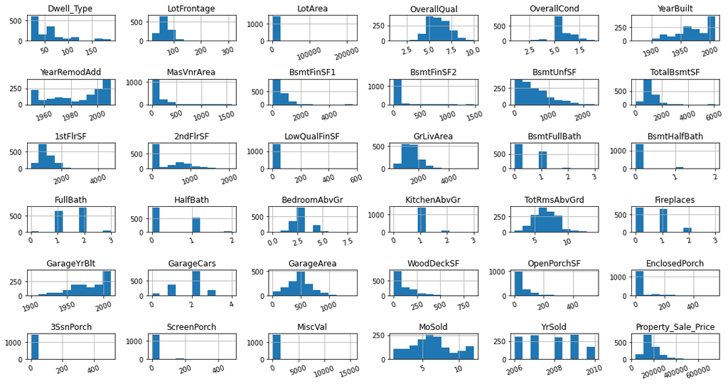

```python
# plot the histogram of numeric variables
# the hist() function considers the numeric variables only, by default
# rotate the x-axis labels by 20 degree using the parameter, 'xrot'
df_house.hist(xrot = 20, )

# adjust the subplots
plt.tight_layout()

# display the plot
plt.show()
```

#### Visualize the target variable

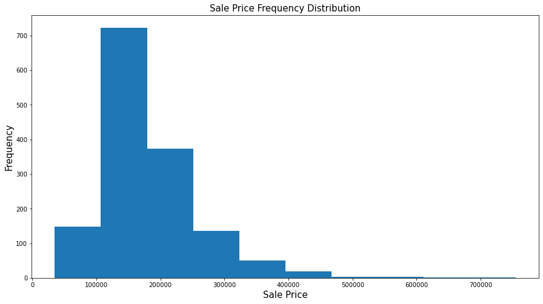

```python
# Sale Price Frequency Distribution
# set the xlabel and the fontsize
plt.xlabel("Sale Price", fontsize=15)

# set the ylabel and the fontsize
plt.ylabel("Frequency", fontsize=15)

# set the title of the plot
plt.title("Sale Price Frequency Distribution", fontsize=15)

# plot the histogram for the target variable
plt.hist(df_house["Property_Sale_Price"])
plt.show()
```

|  | **The above plot shows that the target variable 'Property_Sale_Price' is positively skewed.** |
| --- | --- |

**2. Distribution of categoric variables.**

For the categoric variables, we plot the countplot to check the distribution of the each category in the variable.

```python
categorical
```

[output not shown]

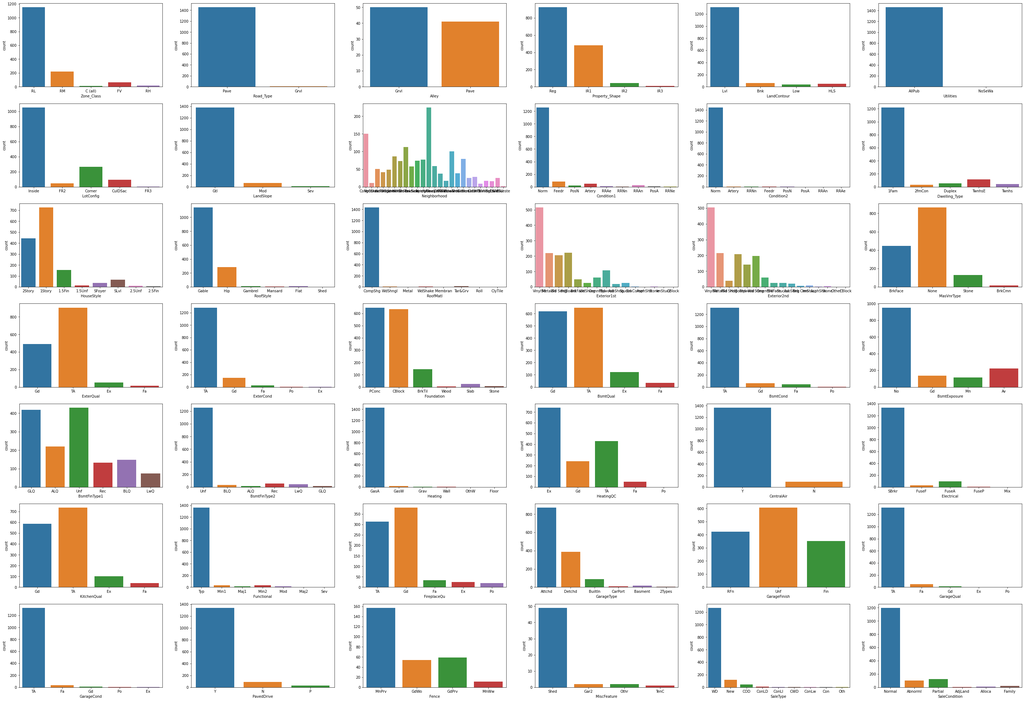

```python
# create a list of all categorical variables
# initiate an empty list to store the categorical variables
categorical=[]

# use for loop to check the data type of each variable
for column in df_house:

    # use 'if' statement with condition to check the categorical type
    if is_string_dtype(df_house[column]):

        # append the variables with 'categoric' data type in the list 'categorical'
        categorical.append(column)

# plot the count plot for each categorical variable
# set the number of rows in the subplot using the parameter, 'nrows'
# set the number of columns in the subplot using the parameter, 'ncols'
# 'figsize' sets the figure size
fig, ax = plt.subplots(7, 6, figsize = (50, 35))

# use for loop to plot the count plot for each variable
for variable, subplot in zip(categorical, ax.flatten()):

    # use countplot() to plot the graph
    # pass the axes for the plot to the parameter, 'ax'
    sns.countplot(df_house[variable], ax = subplot)

# display the plot
plt.show()
```

#### Boxplot of OverallQuality and Property_Sale_Price

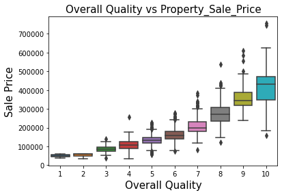

```python
# draw the boxplot for OverallQuality and the Property_Sale_Price
sns.boxplot(y="Property_Sale_Price", x="OverallQual", data= df_house)

# set the title of the plot and the fontsize
plt.title("Overall Quality vs Property_Sale_Price", fontsize=15)

# set the xlabel and the fontsize
plt.xlabel("Overall Quality", fontsize=15)

# set the ylabel and the fontsize
plt.ylabel("Sale Price", fontsize=15)

# display the plot
plt.show()
```

#### Boxplot of Overall Condition and Property_Sale_Price

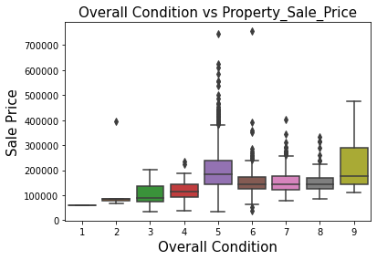

```python
# draw the boxplot for OverallQuality and the Property_Sale_Price
sns.boxplot(y="Property_Sale_Price", x="OverallCond", data= df_house)

# set the title of the plot and the fontsize
plt.title("Overall Condition vs Property_Sale_Price", fontsize=15)

# set the xlabel and the fontsize
plt.xlabel("Overall Condition", fontsize=15)

# set the ylabel and the fontsize
plt.ylabel("Sale Price", fontsize=15)

# display the plot
plt.show()
```

#### Draw the pairplot of the numeric variables

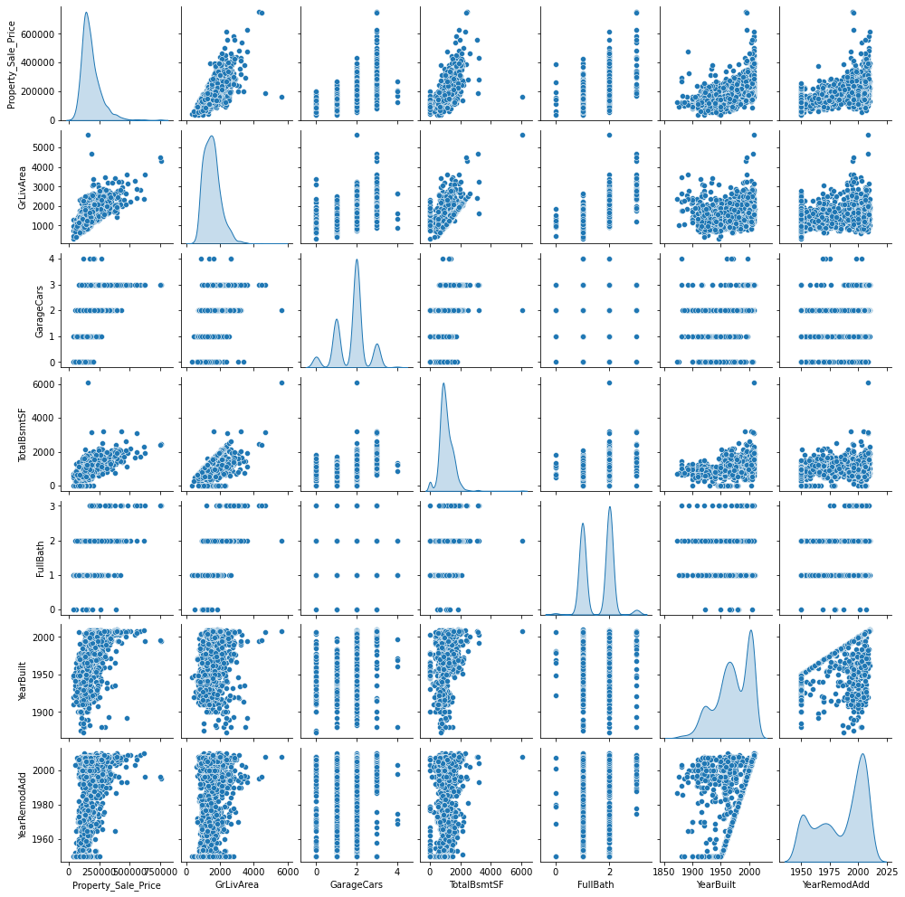

```python
# Pairplot of numeric variables

# select the columns for the pairplot
columns= ["Property_Sale_Price", "GrLivArea", "GarageCars", "TotalBsmtSF", "FullBath", "YearBuilt", "YearRemodAdd"]

# draw the pairplot such that the diagonal should be density plot and the other graphs should be scatter plot
sns.pairplot(df_house[columns], size=2, kind= "scatter", diag_kind="kde")

# display the plot
plt.show()
```

### 4.1.4 Outliers Discovery

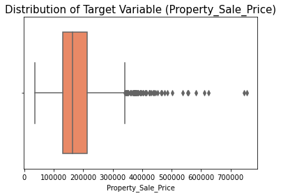

```python
# plot a boxplot of target variable to detect the outliers
sns.boxplot(df_house['Property_Sale_Price'], color='coral')

# set plot label
# set text size using 'fontsize'
plt.title('Distribution of Target Variable (Property_Sale_Price)', fontsize = 15)

# display the plot
plt.show()
```

The above plot shows that there are extreme observations in the target variable. As these values can affect the prediction of the regression model, we remove such observations before building the model.

```python
# remove the observations with the house price greater than or equal to 500000
# consider all the observations with the Property_Sale_Price less than 500000
df_house = df_house[df_house['Property_Sale_Price'] < 500000]

# check the dimension of the data
df_house.shape
```

```
(1451, 78)
```

|  | **The number of observations is reduced to 1451 from 1460 which suggests that we have removed the 9 observations with extremely high house price.** |
| --- | --- |

### 4.1.5 Missing Values

If the missing values are not handled properly we may end up drawing an inaccurate inference about the data.

[figure not shown]

In order to get the count of missing values in each column.

1. Check the missing values
2. Visualize missing values using heatmap
3. Handle missing values
   - For numeric variables
   - For categoric variables

**1. Check the missing values**

```python
# sort the variables on the basis of total null values in the variable
# 'isnull().sum()' returns the number of missing values in each variable
# 'ascending = False' sorts values in the descending order
# the variable with highest number of missing values will appear first
Total = df_house.isnull().sum().sort_values(ascending = False)

# calculate the percentage of missing values
# 'ascending = False' sorts values in the descending order
# the variable with highest percentage of missing values will appear first
Percent = (df_house.isnull().sum()*100/df_house.isnull().count()).sort_values(ascending = False)

# concat the 'Total' and 'Percent' columns using 'concat' function
# 'keys' is the list of column names
# 'axis = 1' concats along the columns
missing_data = pd.concat([Total, Percent], axis = 1, keys = ['Total', 'Percentage of Missing Values'])

# add the column containing data type of each variable
missing_data['Type'] = df_house[missing_data.index].dtypes
missing_data
```

|  | Total | Percentage of Missing Values | Type |
| --- | --- | --- | --- |
| MiscFeature | 1397 | 96.278429 | object |
| Alley | 1360 | 93.728463 | object |
| Fence | 1171 | 80.702963 | object |
| FireplaceQu | 690 | 47.553411 | object |
| LotFrontage | 259 | 17.849759 | float64 |
| GarageCond | 81 | 5.582357 | object |
| GarageType | 81 | 5.582357 | object |
| GarageYrBlt | 81 | 5.582357 | float64 |
| GarageFinish | 81 | 5.582357 | object |
| GarageQual | 81 | 5.582357 | object |
| BsmtFinType2 | 38 | 2.618884 | object |
| BsmtExposure | 38 | 2.618884 | object |
| BsmtQual | 37 | 2.549966 | object |
| BsmtCond | 37 | 2.549966 | object |
| BsmtFinType1 | 37 | 2.549966 | object |
| MasVnrArea | 8 | 0.551344 | float64 |
| MasVnrType | 8 | 0.551344 | object |
| Electrical | 1 | 0.068918 | object |
| Exterior2nd | 0 | 0.000000 | object |
| Exterior1st | 0 | 0.000000 | object |
| RoofStyle | 0 | 0.000000 | object |
| RoofMatl | 0 | 0.000000 | object |
| ExterQual | 0 | 0.000000 | object |
| YearBuilt | 0 | 0.000000 | int64 |
| ExterCond | 0 | 0.000000 | object |
| Foundation | 0 | 0.000000 | object |
| YearRemodAdd | 0 | 0.000000 | int64 |
| Property_Sale_Price | 0 | 0.000000 | int64 |
| OverallCond | 0 | 0.000000 | int64 |
| OverallQual | 0 | 0.000000 | int64 |
| HouseStyle | 0 | 0.000000 | object |
| Dwelling_Type | 0 | 0.000000 | object |
| BsmtFinSF1 | 0 | 0.000000 | int64 |
| Condition1 | 0 | 0.000000 | object |
| Neighborhood | 0 | 0.000000 | object |
| LandSlope | 0 | 0.000000 | object |
| LotConfig | 0 | 0.000000 | object |
| Utilities | 0 | 0.000000 | object |
| LandContour | 0 | 0.000000 | object |
| Property_Shape | 0 | 0.000000 | object |
| Road_Type | 0 | 0.000000 | object |
| LotArea | 0 | 0.000000 | int64 |
| Zone_Class | 0 | 0.000000 | object |
| Condition2 | 0 | 0.000000 | object |
| Heating | 0 | 0.000000 | object |
| BsmtFinSF2 | 0 | 0.000000 | int64 |
| TotRmsAbvGrd | 0 | 0.000000 | int64 |
| SaleType | 0 | 0.000000 | object |
| YrSold | 0 | 0.000000 | int64 |
| MoSold | 0 | 0.000000 | int64 |
| MiscVal | 0 | 0.000000 | int64 |
| ScreenPorch | 0 | 0.000000 | int64 |
| 3SsnPorch | 0 | 0.000000 | int64 |
| EnclosedPorch | 0 | 0.000000 | int64 |
| OpenPorchSF | 0 | 0.000000 | int64 |
| WoodDeckSF | 0 | 0.000000 | int64 |
| PavedDrive | 0 | 0.000000 | object |
| GarageArea | 0 | 0.000000 | int64 |
| GarageCars | 0 | 0.000000 | int64 |
| Fireplaces | 0 | 0.000000 | int64 |
| Functional | 0 | 0.000000 | object |
| KitchenQual | 0 | 0.000000 | object |
| BsmtUnfSF | 0 | 0.000000 | int64 |
| KitchenAbvGr | 0 | 0.000000 | int64 |
| BedroomAbvGr | 0 | 0.000000 | int64 |
| HalfBath | 0 | 0.000000 | int64 |
| FullBath | 0 | 0.000000 | int64 |
| BsmtHalfBath | 0 | 0.000000 | int64 |
| BsmtFullBath | 0 | 0.000000 | int64 |
| GrLivArea | 0 | 0.000000 | int64 |
| LowQualFinSF | 0 | 0.000000 | int64 |
| 2ndFlrSF | 0 | 0.000000 | int64 |
| 1stFlrSF | 0 | 0.000000 | int64 |
| CentralAir | 0 | 0.000000 | object |
| HeatingQC | 0 | 0.000000 | object |
| SaleCondition | 0 | 0.000000 | object |
| TotalBsmtSF | 0 | 0.000000 | int64 |
| Dwell_Type | 0 | 0.000000 | int64 |

[figure not shown]

**The variables 'MiscFeature', 'Alley', 'Fence', 'FireplaceQu', 'LotFrontage', 'GarageCond', 'GarageType', 'GarageYrBlt', 'GarageFinish', 'GarageQual', 'BsmtFinType2', 'BsmtExposure', 'BsmtQual', 'BsmtCond', 'BsmtFinType1', 'MasVnrArea', 'MasVnrType', and 'Electrical' contains the missing values.**

**2. Visualize missing values using heatmap**

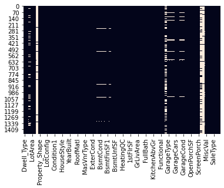

```python
# plot heatmap to visualize the null values in each column
# 'cbar = False' does not show the color axis
sns.heatmap(df_house.isnull(), cbar=False)

# display the plot
plt.show()
```

The horizontal lines in the heatmap correspond to the missing values. This is a visual representation of the previous output.

**3. Handle missing values**

**Replace the missing values in numerical variables**

```python
# consider the numeric variables with missing values
# pass the condition to filter the variables with number of missing values greater than zero and numeric data type
num_missing_values = missing_data[(missing_data['Total'] > 0) & (missing_data['Type'] != 'object')]
num_missing_values
```

|  | Total | Percentage of Missing Values | Type |
| --- | --- | --- | --- |
| LotFrontage | 259 | 17.849759 | float64 |
| GarageYrBlt | 81 | 5.582357 | float64 |
| MasVnrArea | 8 | 0.551344 | float64 |

For the numerical variables, replace the missing values by their respective mean, median or mode as per the requirement.

```python
# the variable 'LotFrontage' is positively skewed
# fill the missing values with its median value using fillna()
df_house['LotFrontage'] = df_house['LotFrontage'].fillna(df_house['LotFrontage'].median())
```

The dataframe `missing_data` shows that, all the variables containing the garage information have 81 missing values. This indicates that there are 81 observations for which garage facility is not available. Thus, we replace the missing values in the numeric variable `GarageYrBlt` by 0.

```python
# replace missing values in 'GarageYrBlt' with 0 using fillna()
df_house['GarageYrBlt'] = df_house['GarageYrBlt'].fillna(0)
```

```python
# the variable 'MasVnrArea' is positively skewed
# fill the missing values with its median value using fillna()
df_house['MasVnrArea'] = df_house['MasVnrArea'].fillna(df_house['MasVnrArea'].median())
```

**Replace the missing values in categorical variables**

```python
# consider the categoric variables with missing values
# pass the condition to filter the variables with number of missing values greater than zero and categoric data type
cat_missing_values = missing_data[(missing_data['Total'] > 0) & (missing_data['Type'] == 'object')]
cat_missing_values
```

|  | Total | Percentage of Missing Values | Type |
| --- | --- | --- | --- |
| MiscFeature | 1397 | 96.278429 | object |
| Alley | 1360 | 93.728463 | object |
| Fence | 1171 | 80.702963 | object |
| FireplaceQu | 690 | 47.553411 | object |
| GarageCond | 81 | 5.582357 | object |
| GarageType | 81 | 5.582357 | object |
| GarageFinish | 81 | 5.582357 | object |
| GarageQual | 81 | 5.582357 | object |
| BsmtFinType2 | 38 | 2.618884 | object |
| BsmtExposure | 38 | 2.618884 | object |
| BsmtQual | 37 | 2.549966 | object |
| BsmtCond | 37 | 2.549966 | object |
| BsmtFinType1 | 37 | 2.549966 | object |
| MasVnrType | 8 | 0.551344 | object |
| Electrical | 1 | 0.068918 | object |

```python
# according to the data definition, 'NA' denotes the absence of miscellaneous feature
# replace NA values in 'MiscFeature' with a valid value, 'None'
df_house['MiscFeature'] = df_house['MiscFeature'].fillna('None')
```

```python
# according to the data definition, 'NA' denotes the absence of alley access
# replace NA values in 'Alley' with a valid value, 'No alley access'
df_house['Alley'] = df_house['Alley'].fillna('No alley access')
```

```python
# according to the data definition, 'NA' denotes the absence of fence
# replace NA values in 'Fence' with a valid value, 'No Fence'
df_house['Fence'] = df_house['Fence'].fillna('No Fence')
```

```python
# according to the data definition, 'NA' denotes the absence of fireplace
# replace null values in 'FireplaceQu' with a valid value, 'No Fireplace'
df_house['FireplaceQu'] = df_house['FireplaceQu'].fillna('No Fireplace')
```

The dataframe `missing_data` shows that, all the variables containing the garage information have 81 missing values. This indicates that there are 81 observations for which garage facility is not available. Thus, we replace the missing values in the categoric variables representing the garage by `No Garage`.

```python
# use 'for loop' to replace NA values in the below columns with a valid value, 'No Garage'
# 'inplace = True' replace the null values in the original data
for col in ['GarageCond', 'GarageType', 'GarageFinish', 'GarageQual']:
    df_house[col].fillna('No Garage', inplace = True)
```

```python
# according to the data definition, 'NA' denotes the absence of basement in the variabels 'BsmtQual', 'BsmtCond',
# 'BsmtExposure', 'BsmtFinType1','BsmtFinType2'
# use 'for loop' to replace NA values with 'No Basement' in these columns
# 'inplace = True' replace the null values in the original data
for col in ['BsmtFinType2', 'BsmtExposure', 'BsmtQual','BsmtCond','BsmtFinType1']:
    df_house[col].fillna('No Basement', inplace = True)
```

```python
# according to the data definition, 'NA' denotes the absence of masonry veneer
# replace NA values in 'MasVnrType' with a valid value, 'None'
df_house['MasVnrType'] = df_house['MasVnrType'].fillna('None')
```

```python
# replace the null values in 'Electrical' with its mode
# calculate the mode of the 'Electrical'
mode_electrical = df_house['Electrical'].mode()

# print mode of the 'Electrical'
print(mode_electrical)
```

```
0    SBrkr
dtype: object
```

```python
# replace NA values in 'Electrical' with its mode, i.e. 'SBrkr'
df_house['Electrical'].fillna('SBrkr' , inplace = True)
```

After replacing the null values for the required variables, recheck the null values.

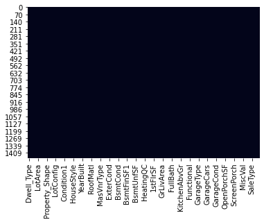

```python
# recheck the null values
# plot heatmap to visualize the null values in each column
# 'cbar = False' does not show the color axis
sns.heatmap(df_house.isnull(), cbar=False)

# display the plot
plt.show()
```

|  | **The above plot shows that there are no missing values in the data.** |
| --- | --- |

### 4.1.6 Study correlation

|  | To check the correlation between numerical variables, we perform the following steps: 1. Compute a correlation matrix 2. Plot a heatmap for the correlation matrix |
| --- | --- |

**1. Compute a correlation matrix**

```python
# use the corr() function to generate the correlation matrix of the numeric variables
corrmat = df_house.corr()

# print the correlation matrix
shape.corrmat
```

[output not shown]

**2. Plot the heatmap for the diagonal correlation matrix**

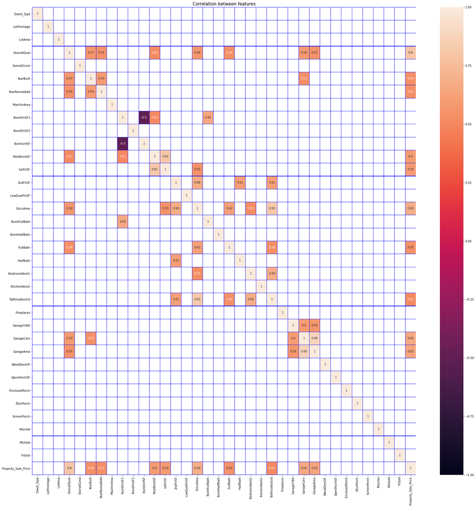

```python
correlation=df_house.corr()
plt.figure(figsize=(30, 30))
sns.heatmap(correlation[(correlation >= 0.5) | (correlation <= -0.5)],
            annot=True,linewidths=.1,linecolor="blue",vmax = 1, vmin = -1)
plt.title('Correlation between features', fontsize=15)
plt.show()
```

```python
# set the plot size
# pass the required height and width to the parameter, 'figsize'
plt.figure(figsize = (30,20))

# use 'mask' to plot a upper triangular correlation matrix
# 'tril_indices_from' returns the indices for the lower-triangle of matrix
# 'k = -1' consider the diagonal of the matrix
mask = np.zeros_like(corrmat)
mask[np.triu_indices_from(mask, k = 1)] = True

# plot the heat map
# corr: give the correlation matrix
# cmap: color code used for plotting
# vmax: gives a maximum range of values for the chart
# vmin: gives a minimum range of values for the chart
# annot: prints the correlation values in the chart
# annot_kws: sets the font size of the annotation
# mask: mask the upper traingular matrix values
sns.heatmap(corrmat, cmap = 'Blues', vmax = 1.0, vmin = -1.0, annot = True, annot_kws = {"size": 12}, mask = mask)

# set the size of x and y axes labels
# set text size using 'fontsize'
plt.xticks(fontsize = 15)
plt.yticks(fontsize = 15)

# display the plot
plt.show()
```

[figure not shown]

The diagonal entries are all '1' which represents the correlation of the variable with itself. The dark blue squares represent the variables with strong positive correlation.  
The above plot shows that there is highest positive correlation (= 0.88) between the variables 'GarageArea' and 'GarageCars'. Also there is strong positive correlation between the pairs (1StFlrSF, TotalBsmtSF) and (TotRmsAbvGrd, GrlivArea). These variables may involved in multicollinearity.  
No two variables have strong negative correlation in the dataset.

|  | **Correlation does not imply causation. In other words, if two variables are correlated, it does not mean that one variable caused the other.** |
| --- | --- |

|  | **I love to know more:** [Why correlation does not imply causation](https://bit.ly/2PBvA8T) |
| --- | --- |

### 4.1.7 Analyze Relationships Between Target and Categorical Variables

|  | **Plot the box-and-whisker plot for visualizing relationships between target and categorical variables.** |
| --- | --- |

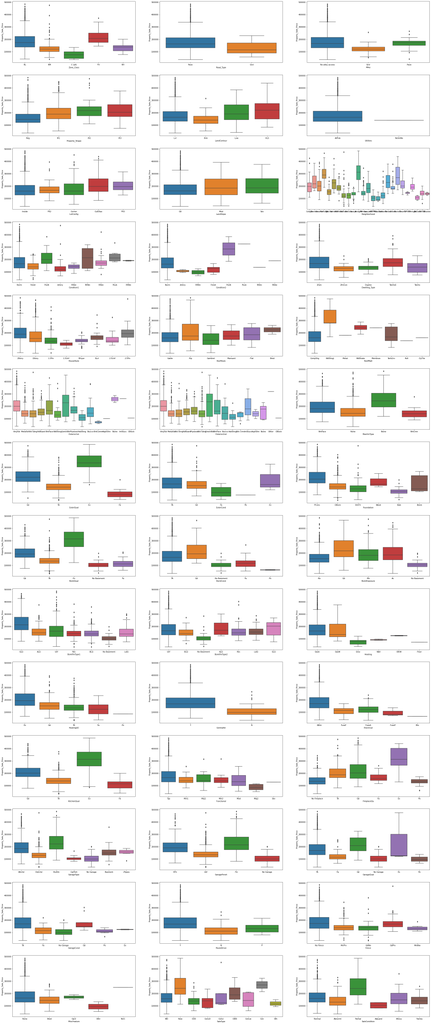

```python
# create a list of all categorical variables
# initiate an empty list to store the categorical variables
categorical=[]

# use for loop to check the data type of each variable
for column in df_house:

    # use 'if' statement with condition to check the categorical type
    if is_string_dtype(df_house[column]):

        # append the variables with 'categoric' data type in the list 'categorical'
        categorical.append(column)

# plot the boxplot for each categorical and target variable
# set the number of rows in the subplot using the parameter, 'nrows'
# set the number of columns in the subplot using the parameter, 'ncols'
# 'figsize' sets the figure size
fig, ax = plt.subplots(nrows = 14, ncols = 3, figsize = (40, 100))

# use for loop to plot the boxplot for each categoric and target variable
for variable, subplot in zip(categorical, ax.flatten()):

    # use boxplot() to plot the graph
    # pass the axes for the plot to the parameter, 'ax'
    sns.boxplot(x = variable, y = 'Property_Sale_Price', data = df_house, ax = subplot)

# display the plot
plt.show()
```

[output not shown]

## 4.2 Prepare the Data

### 4.2.1 Check for Normality

[figure not shown]

In order to check for normality of our target variable,  
1. Plot a histogram and also perform the Shapiro-Wilk test  
2. If the data is not normally distributed, use log transformation to get near normally distributed data  
3. Recheck for normality by plotting histogram and performing Shapiro-Wilk test

**1. Plot a histogram and also perform the Shapiro-Wilk test**

To plot a histogram, we use the `hist()` from the matplotlib library.

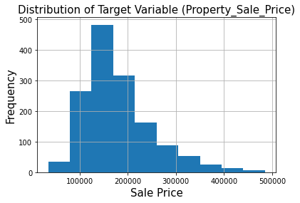

```python
# check the distribution of target variable
df_house.Property_Sale_Price.hist()

# add plot and axes labels
# set text size using 'fontsize'
plt.title('Distribution of Target Variable (Property_Sale_Price)', fontsize = 15)
plt.xlabel('Sale Price', fontsize = 15)
plt.ylabel('Frequency', fontsize = 15)

# display the plot
plt.show()
```

|  | **From the above plot, we can notice that the variable 'Property_Sale_Price' is right skewed and not normally distributed.** |
| --- | --- |

|  | **We should not only make conclusions through visual representations or only using a statistical test but perform multiple ways to get the best insights.** |
| --- | --- |

Let us perform from Shapiro-Wilk test to check the normality of the target variable.

The null and alternate hypothesis of Shapiro-Wilk test is as follows:

**H<sub>o</sub>: The data is normally distributed**

**H<sub>1</sub>: The data is not normally distributed**

```python
# normality test using shapiro()
# the test returns the the test statistics and the p-value of the test
stat, p = shapiro(df_house.Property_Sale_Price)

# to print the numeric outputs of the Shapiro-Wilk test upto 3 decimal places
# %.3f: returns the a floating point with 3 decimal digit accuracy
# the '%' holds the place where the number is to be printed
print('Statistics=%.3f, p-value=%.3f' % (stat, p))

# display the conclusion
# set the level of significance to 0.05
alpha = 0.05

# if the p-value is greater than alpha print we accept alpha
# if the p-value is less than alpha print we reject alpha
if p > alpha:
    print('The data is normally distributed (fail to reject H0)')
else:
    print('The data is not normally distributed (reject H0)')
```

```
Statistics=0.919, p-value=0.000
The data is not normally distributed (reject H0)
```

[figure not shown]

[figure not shown]

**Shaprio Wilk Test does not work if the number of observations are more than 5000. However Shapiro Wilk test is more robust than other tests. In case where the observations are more than 5000, other tests like Anderson Darling test or Jarque Bera test may also be used.**

**2. If the data is not normally distributed, use log transformation to get near normally distributed data**

As mentioned above we opt for log transformation. The log transformation can be used to make highly skewed distributions less skewed. We use `np.log()` to log transform the 'Property_Sale_Price' variable. We also store the transformed variable into our data frame with a new name, `log_Property_Sale_Price`.

```python
# log transformation for normality using np.log()
df_house['log_Property_Sale_Price'] = np.log(df_house['Property_Sale_Price'])

# display first 5 rows of the data
df_house.head()
```

|  | Dwell_Type | Zone_Class | LotFrontage | LotArea | Road_Type | Alley | Property_Shape | LandContour | Utilities | LotConfig | LandSlope | Neighborhood | Condition1 | Condition2 | Dwelling_Type | HouseStyle | OverallQual | OverallCond | YearBuilt | YearRemodAdd | RoofStyle | RoofMatl | Exterior1st | Exterior2nd | MasVnrType | MasVnrArea | ExterQual | ExterCond | Foundation | … |
| --- | --- | --- | --- | --- | --- | --- | --- | --- | --- | --- | --- | --- | --- | --- | --- | --- | --- | --- | --- | --- | --- | --- | --- | --- | --- | --- | --- | --- | --- | --- |
| 0 | 60 | RL | 65.0 | 8450 | Pave | No alley access | Reg | Lvl | AllPub | Inside | Gtl | CollgCr | Norm | Norm | 1Fam | 2Story | 7 | 5 | 2003 | 2003 | Gable | CompShg | VinylSd | VinylSd | BrkFace | 196.0 | Gd | TA | PConc | … |
| 1 | 20 | RL | 80.0 | 9600 | Pave | No alley access | Reg | Lvl | AllPub | FR2 | Gtl | Veenker | Feedr | Norm | 1Fam | 1Story | 6 | 8 | 1976 | 1976 | Gable | CompShg | MetalSd | MetalSd | None | 0.0 | TA | TA | CBlock | … |
| 2 | 60 | RL | 68.0 | 11250 | Pave | No alley access | IR1 | Lvl | AllPub | Inside | Gtl | CollgCr | Norm | Norm | 1Fam | 2Story | 7 | 5 | 2001 | 2002 | Gable | CompShg | VinylSd | VinylSd | BrkFace | 162.0 | Gd | TA | PConc | … |
| 3 | 70 | RL | 60.0 | 9550 | Pave | No alley access | IR1 | Lvl | AllPub | Corner | Gtl | Crawfor | Norm | Norm | 1Fam | 2Story | 7 | 5 | 1915 | 1970 | Gable | CompShg | Wd Sdng | Wd Shng | None | 0.0 | TA | TA | BrkTil | … |
| 4 | 60 | RL | 84.0 | 14260 | Pave | No alley access | IR1 | Lvl | AllPub | FR2 | Gtl | NoRidge | Norm | Norm | 1Fam | 2Story | 8 | 5 | 2000 | 2000 | Gable | CompShg | VinylSd | VinylSd | BrkFace | 350.0 | Gd | TA | PConc | … |

**3. Recheck for normality by plotting histogram and performing Shapiro-Wilk test**

Let us first plot a histogram of `log_Property_Sale_Price`.

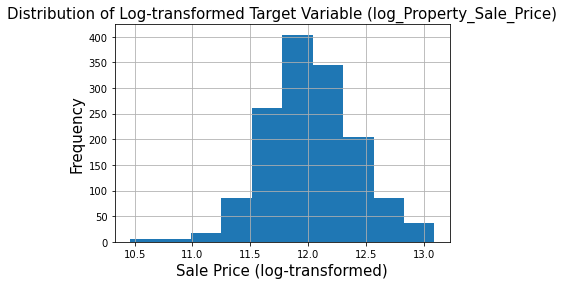

```python
# recheck for normality
# plot the histogram using hist
df_house.log_Property_Sale_Price.hist()

# add plot and axes labels
# set text size using 'fontsize'
plt.title('Distribution of Log-transformed Target Variable (log_Property_Sale_Price)', fontsize = 15)
plt.xlabel('Sale Price (log-transformed)', fontsize = 15)
plt.ylabel('Frequency', fontsize = 15)

# display the plot
plt.show()
```

|  | **It can be seen that the variable log_Property_Sale_Price is near normally distributed. However we again confirm by Shapiro-Wilk test.** |
| --- | --- |

Let us perform Shapiro-Wilk test.

```python
# check the normality by Shapiro-Wilk test
# the test returns the the test statistics and the p-value of the test
stat, pv = shapiro(df_house['log_Property_Sale_Price'])

# to print the numeric outputs of the Shapiro-Wilk test upto 3 decimal places
# %.3f: returns the a floating point with 3 decimal digit accuracy
# the '%' holds the place where the number is to be printed
print('Statistics=%.3f, p-value=%.3f' % (stat, pv))

# display the conclusion
# set the level of significance to 0.05
alpha = 0.05

# if the p-value is greater than alpha print we accept alpha
# if the p-value is less than alpha print we reject alpha
if pv > alpha:
    print('The data is normally distributed (fail to reject H0)')
else:
    print('The data is not normally distributed (reject H0)')
```

```
Statistics=0.992, p-value=0.000
The data is not normally distributed (reject H0)
```

```python
# find the skewness of the variable log_Property_Sale_Price
df_house['log_Property_Sale_Price'].skew()
```

```
-0.03836503763294778
```

[output not shown]

### 4.2.2 Dummy Encode the Categorical Variables

[figure not shown]

We need to perform dummy encoding on our categorical variables before we proceed; since the method of OLS works only on the numeric data.  
In order to dummy encode, we do the following:  
1. Filter numerical and categorical variables  
2. Dummy encode the catergorical variables  
3. Concatenate numerical and dummy encoded categorical variables

**1. Filter numerical and categorical variables**

```python
# filter the numerical features in the dataset using select_dtypes()
# include=np.number: selects the numeric features
df_numeric_features = df_house.select_dtypes(include=np.number)

# display the numeric features
df_numeric_features.columns
```

```
Index(['Dwell_Type', 'LotFrontage', 'LotArea', 'OverallQual', 'OverallCond',
       'YearBuilt', 'YearRemodAdd', 'MasVnrArea', 'BsmtFinSF1', 'BsmtFinSF2',
       'BsmtUnfSF', 'TotalBsmtSF', '1stFlrSF', '2ndFlrSF', 'LowQualFinSF',
       'GrLivArea', 'BsmtFullBath', 'BsmtHalfBath', 'FullBath', 'HalfBath',
       'BedroomAbvGr', 'KitchenAbvGr', 'TotRmsAbvGrd', 'Fireplaces',
       'GarageYrBlt', 'GarageCars', 'GarageArea', 'WoodDeckSF', 'OpenPorchSF',
       'EnclosedPorch', '3SsnPorch', 'ScreenPorch', 'MiscVal', 'MoSold',
       'YrSold', 'Property_Sale_Price', 'log_Property_Sale_Price'],
      dtype='object')
```

```python
# filter the categorical features in the dataset using select_dtypes()
# include=[np.object]: selects the categoric features
df_categoric_features = df_house.select_dtypes(include = object)

# display categorical features
df_categoric_features.columns
```

```
Index(['Zone_Class', 'Road_Type', 'Alley', 'Property_Shape', 'LandContour',
       'Utilities', 'LotConfig', 'LandSlope', 'Neighborhood', 'Condition1',
       'Condition2', 'Dwelling_Type', 'HouseStyle', 'RoofStyle', 'RoofMatl',
       'Exterior1st', 'Exterior2nd', 'MasVnrType', 'ExterQual', 'ExterCond',
       'Foundation', 'BsmtQual', 'BsmtCond', 'BsmtExposure', 'BsmtFinType1',
       'BsmtFinType2', 'Heating', 'HeatingQC', 'CentralAir', 'Electrical',
       'KitchenQual', 'Functional', 'FireplaceQu', 'GarageType',
       'GarageFinish', 'GarageQual', 'GarageCond', 'PavedDrive', 'Fence',
       'MiscFeature', 'SaleType', 'SaleCondition'],
      dtype='object')
```

**2. Dummy encode the catergorical variables**

```python
# use 'get_dummies()' from pandas to create dummy variables
# use 'drop_first = True' to create (n-1) dummy variables
dummy_encoded_variables = pd.get_dummies(df_categoric_features, drop_first = True)
```

**3. Concatenate numerical and dummy encoded categorical variables**

```python
# concatenate the numerical and dummy encoded categorical variables using concat()
# axis=1: specifies that the concatenation is column wise
df_house_dummy = pd.concat([df_numeric_features, dummy_encoded_variables], axis=1)

# display data with dummy variables
df_house_dummy.head()
```

|  | Dwell_Type | LotFrontage | LotArea | OverallQual | OverallCond | YearBuilt | YearRemodAdd | MasVnrArea | BsmtFinSF1 | BsmtFinSF2 | BsmtUnfSF | TotalBsmtSF | 1stFlrSF | 2ndFlrSF | LowQualFinSF | GrLivArea | BsmtFullBath | BsmtHalfBath | FullBath | HalfBath | BedroomAbvGr | KitchenAbvGr | TotRmsAbvGrd | Fireplaces | GarageYrBlt | GarageCars | GarageArea | WoodDeckSF | OpenPorchSF | … |
| --- | --- | --- | --- | --- | --- | --- | --- | --- | --- | --- | --- | --- | --- | --- | --- | --- | --- | --- | --- | --- | --- | --- | --- | --- | --- | --- | --- | --- | --- | --- |
| 0 | 60 | 65.0 | 8450 | 7 | 5 | 2003 | 2003 | 196.0 | 706 | 0 | 150 | 856 | 856 | 854 | 0 | 1710 | 1 | 0 | 2 | 1 | 3 | 1 | 8 | 0 | 2003.0 | 2 | 548 | 0 | 61 | … |
| 1 | 20 | 80.0 | 9600 | 6 | 8 | 1976 | 1976 | 0.0 | 978 | 0 | 284 | 1262 | 1262 | 0 | 0 | 1262 | 0 | 1 | 2 | 0 | 3 | 1 | 6 | 1 | 1976.0 | 2 | 460 | 298 | 0 | … |
| 2 | 60 | 68.0 | 11250 | 7 | 5 | 2001 | 2002 | 162.0 | 486 | 0 | 434 | 920 | 920 | 866 | 0 | 1786 | 1 | 0 | 2 | 1 | 3 | 1 | 6 | 1 | 2001.0 | 2 | 608 | 0 | 42 | … |
| 3 | 70 | 60.0 | 9550 | 7 | 5 | 1915 | 1970 | 0.0 | 216 | 0 | 540 | 756 | 961 | 756 | 0 | 1717 | 1 | 0 | 1 | 0 | 3 | 1 | 7 | 1 | 1998.0 | 3 | 642 | 0 | 35 | … |
| 4 | 60 | 84.0 | 14260 | 8 | 5 | 2000 | 2000 | 350.0 | 655 | 0 | 490 | 1145 | 1145 | 1053 | 0 | 2198 | 1 | 0 | 2 | 1 | 4 | 1 | 9 | 1 | 2000.0 | 3 | 836 | 192 | 84 | … |

```python
# check the shape of the dataframe
df_house_dummy.shape
```

```
(1451, 257)
```

[output not shown]

|  | **There are various forms of encoding like n-1 dummy encoding, one hot encoding, label encoding, frequency encoding.** |
| --- | --- |

|  | **I love to know more:** 1. FAQ: What is Dummy Coding? [2. Encoding Categorical Features](https://bit.ly/2q9Omt9) |
| --- | --- |

|  | **Let us now proceed to train models. We shall begin by fitting a linear regression model using the method of ordinary least square(OLS).** |
| --- | --- |

# 5. Linear Regression (OLS)

## 5.1 Multiple Linear Regression - Full Model - with Log Transformed Dependent Variable (OLS)

[figure not shown]

In order to build the model, we do the following:  
1. Split the data into training and test sets  
2. Build model using sm.OLS().fit()  
3. Predict the values using test set  
4. Compute accuracy measures  
5. Tabulate the results

**1. Split the data into training and test sets**

Statmodels linear regression function (OLS) does not include the intercept term by default. Thus, we add the intercept column to the dataset.

```python
# add the intercept column using 'add_constant()'
df_house_dummy = sm.add_constant(df_house_dummy)

# separate the independent and dependent variables
# drop(): drops the specified columns
# axis=1: specifies that the column is to be dropped
X = df_house_dummy.drop(['Property_Sale_Price','log_Property_Sale_Price'], axis = 1)

# extract the target variable from the data set
y = df_house_dummy[['Property_Sale_Price','log_Property_Sale_Price']]

# split data into train subset and test subset for predictor and target variables
# 'test_size' returns the proportion of data to be included in the test set
# set 'random_state' to generate the same dataset each time you run the code
X_train, X_test, y_train, y_test = train_test_split(X, y, test_size = 0.3, random_state = 1)

# check the dimensions of the train & test subset for
# print dimension of predictors train set
print("The shape of X_train is:",X_train.shape)

# print dimension of predictors test set
print("The shape of X_test is:",X_test.shape)

# print dimension of target train set
print("The shape of y_train is:",y_train.shape)

# print dimension of target test set
print("The shape of y_test is:",y_test.shape)
```

```
The shape of X_train is: (1015, 256)
The shape of X_test is: (436, 256)
The shape of y_train is: (1015, 2)
The shape of y_test is: (436, 2)
```

**2. Build model using sm.OLS().fit()**

```python
# build a full model using OLS()
# consider the log of sales price as the target variable
# use fit() to fit the model on train data
linreg_full_model_withlog = sm.OLS(y_train['log_Property_Sale_Price'], X_train).fit()
```

```python
# print the summary output
linreg_full_model_withlog.summary()
```

OLS Regression Results

| Dep. Variable: | log_Property_Sale_Price | R-squared: | 0.949 |
| --- | --- | --- | --- |
| Model: | OLS | Adj. R-squared: | 0.933 |
| Method: | Least Squares | F-statistic: | 60.22 |
| Date: | Thu, 25 Mar 2021 | Prob (F-statistic): | 0.00 |
| Time: | 17:15:02 | Log-Likelihood: | 1056.7 |
| No. Observations: | 1015 | AIC: | -1633. |
| Df Residuals: | 775 | BIC: | -452.0 |
| Df Model: | 239 |  |  |
| Covariance Type: | nonrobust |  |  |

|  | coef | std err | t | P>\|t\| | [0.025 | 0.975] |
| --- | --- | --- | --- | --- | --- | --- |
| const | 6.6498 | 4.642 | 1.433 | 0.152 | -2.463 | 15.762 |
| Dwell_Type | -1.405e-05 | 0.000 | -0.030 | 0.976 | -0.001 | 0.001 |
| LotFrontage | 0.0003 | 0.000 | 1.372 | 0.170 | -0.000 | 0.001 |
| LotArea | 3.351e-06 | 5.86e-07 | 5.721 | 0.000 | 2.2e-06 | 4.5e-06 |
| OverallQual | 0.0359 | 0.006 | 6.474 | 0.000 | 0.025 | 0.047 |
| OverallCond | 0.0379 | 0.005 | 8.258 | 0.000 | 0.029 | 0.047 |
| YearBuilt | 0.0023 | 0.000 | 5.313 | 0.000 | 0.001 | 0.003 |
| YearRemodAdd | 0.0009 | 0.000 | 3.018 | 0.003 | 0.000 | 0.001 |
| MasVnrArea | 4.896e-06 | 3.3e-05 | 0.148 | 0.882 | -5.99e-05 | 6.97e-05 |
| BsmtFinSF1 | 6.645e-05 | 1.58e-05 | 4.206 | 0.000 | 3.54e-05 | 9.75e-05 |
| BsmtFinSF2 | 3.518e-05 | 3.16e-05 | 1.115 | 0.265 | -2.68e-05 | 9.72e-05 |
| BsmtUnfSF | -5.688e-06 | 1.49e-05 | -0.381 | 0.703 | -3.5e-05 | 2.36e-05 |
| TotalBsmtSF | 9.595e-05 | 2.22e-05 | 4.329 | 0.000 | 5.24e-05 | 0.000 |
| 1stFlrSF | 9.633e-05 | 3.47e-05 | 2.773 | 0.006 | 2.81e-05 | 0.000 |
| 2ndFlrSF | 8.032e-05 | 3.23e-05 | 2.487 | 0.013 | 1.69e-05 | 0.000 |
| LowQualFinSF | -1.383e-05 | 7.71e-05 | -0.179 | 0.858 | -0.000 | 0.000 |
| GrLivArea | 0.0002 | 3.02e-05 | 5.397 | 0.000 | 0.000 | 0.000 |
| BsmtFullBath | 0.0206 | 0.011 | 1.932 | 0.054 | -0.000 | 0.041 |
| BsmtHalfBath | 0.0172 | 0.016 | 1.092 | 0.275 | -0.014 | 0.048 |
| FullBath | 0.0057 | 0.012 | 0.466 | 0.641 | -0.018 | 0.030 |
| HalfBath | 0.0112 | 0.011 | 1.020 | 0.308 | -0.010 | 0.033 |
| BedroomAbvGr | 0.0171 | 0.008 | 2.264 | 0.024 | 0.002 | 0.032 |
| KitchenAbvGr | -0.0407 | 0.034 | -1.190 | 0.235 | -0.108 | 0.026 |
| TotRmsAbvGrd | -0.0021 | 0.005 | -0.403 | 0.687 | -0.012 | 0.008 |
| Fireplaces | 0.0141 | 0.014 | 1.033 | 0.302 | -0.013 | 0.041 |
| GarageYrBlt | -3.037e-05 | 0.000 | -0.091 | 0.927 | -0.001 | 0.001 |
| GarageCars | 0.0301 | 0.012 | 2.423 | 0.016 | 0.006 | 0.054 |
| GarageArea | 7.649e-05 | 4.46e-05 | 1.714 | 0.087 | -1.11e-05 | 0.000 |
| WoodDeckSF | 6.604e-05 | 3.29e-05 | 2.006 | 0.045 | 1.41e-06 | 0.000 |
| OpenPorchSF | 0.0001 | 6.31e-05 | 2.081 | 0.038 | 7.44e-06 | 0.000 |

[output cut: 226 more lines]

| Omnibus: | 227.118 | Durbin-Watson: | 1.955 |
| --- | --- | --- | --- |
| Prob(Omnibus): | 0.000 | Jarque-Bera (JB): | 1827.845 |
| Skew: | -0.790 | Prob(JB): | 0.00 |
| Kurtosis: | 9.381 | Cond. No. | 2.39e+19 |

Notes:  
[1] Standard Errors assume that the covariance matrix of the errors is correctly specified.  
[2] The smallest eigenvalue is 3.84e-28. This might indicate that there are  
strong multicollinearity problems or that the design matrix is singular.

[figure not shown]

[figure not shown]

Condition Number : One way to assess multicollinearity is to compute the condition number(CN). If CN is less than 100, there is no multicollinearity. If CN is between 100 and 1000, there is moderate multicollinearity and if CN is greater 1000 there is severe multicollinearity in the data.  
Durbin-Watson : The Durbin-Watson statistic will always have a value between 0 and 4. A value of 2.0 means that there is no autocorrelation detected in the sample. Values from 0 to less than 2 indicate positive autocorrelation and values from from 2 to 4 indicate negative autocorrelation.

**3. Predict the values using test set**

```python
# predict the 'log_Property_Sale_Price' using predict()
linreg_full_model_withlog_predictions = linreg_full_model_withlog.predict(X_test)
```

[output not shown]

```python
linreg_full_model_withlog_predictions.count()
```

```
436
```

|  | **Note that the predicted values are log transformed Property_Sale_Price. In order to get Property_Sale_Price values, we take the antilog of these predicted values by using the function np.exp()** |
| --- | --- |

```python
# take the exponential of predictions using np.exp()
predicted_Property_Sale_Price = np.exp(linreg_full_model_withlog_predictions)

# extract the 'Property_Sale_Price' values from the test data
actual_Property_Sale_Price = y_test['Property_Sale_Price']
```

[output not shown]

**4. Compute accuracy measures**

Now we calculate accuray measures Root-mean-square-error (RMSE), R-squared and Adjusted R-squared.

```python
# calculate rmse using rmse()
linreg_full_model_withlog_rmse = rmse(actual_Property_Sale_Price, predicted_Property_Sale_Price)

# calculate R-squared using rsquared
linreg_full_model_withlog_rsquared = linreg_full_model_withlog.rsquared

# calculate Adjusted R-Squared using rsquared_adj
linreg_full_model_withlog_rsquared_adj = linreg_full_model_withlog.rsquared_adj
```

[output not shown]

**5. Tabulate the results**

```python
# create the result table for all accuracy scores
# accuracy measures considered for model comparision are RMSE, R-squared value and Adjusted R-squared value
# create a list of column names
cols = ['Model', 'RMSE', 'R-Squared', 'Adj. R-Squared']

# create a empty dataframe of the colums
# columns: specifies the columns to be selected
result_tabulation = pd.DataFrame(columns = cols)

# compile the required information
linreg_full_model_withlog_metrics = pd.Series({'Model': "Linreg full model with log of target variable ",
                     'RMSE':linreg_full_model_withlog_rmse,
                     'R-Squared': linreg_full_model_withlog_rsquared,
                     'Adj. R-Squared': linreg_full_model_withlog_rsquared_adj
                   })

# append our result table using append()
# ignore_index=True: does not use the index labels
# python can only append a Series if ignore_index=True or if the Series has a name
result_tabulation = result_tabulation.append(linreg_full_model_withlog_metrics, ignore_index = True)

# print the result table
result_tabulation
```

|  | **Let us also take a look at building a linear regression full model without performing any kind of transformation on target variable.** |
| --- | --- |

## 5.2 Multiple Linear Regression - Full Model - without Log Transformed Dependent Variable (OLS)

In this section we build a full model with linear regression using OLS (Ordinary Least Square) technique. By full model we indicate that we consider all the independent variables that are present in the dataset.

In this case, we do not consider any kind of transformation on the dependent variable, we use the 'Property_Sale_Price' variable as it is.

[figure not shown]

We do not need to do the train and test split again since it has been done while building the previous model  
In order to build the model, we do the following:  
1. Build model using sm.OLS().fit()  
2. Predict the values using test set  
3. Compute accuracy measures  
4. Tabulate the results

**1. Build model using sm.OLS().fit()**

```python
# build a full model using OLS()
# consider the Property_Sale_Price as the target variable
# use fit() to fit the model on train data
linreg_full_model_withoutlog = sm.OLS(y_train['Property_Sale_Price'], X_train).fit()

# print the summary output
print(linreg_full_model_withoutlog.summary())
```

[figure not shown]

**This model explains 94.4% of the variation in dependent variable Property_Sale_Price. The Durbin-Watson test statistics is 2.002 and indicates that there is no autocorrelation. The Condition Number 3.23e+19 suggests that there is severe multicollinearity in the data.**

**2. Predict the values using test set**

```python
# predict the 'Property_Sale_Price' using predict()
linreg_full_model_withoutlog_predictions = linreg_full_model_withoutlog.predict(X_test)
```

**3. Compute accuracy measures**

Now we calculate accuray measures Root-mean-square-error (RMSE), R-squared and Adjusted R-squared.

```python
# calculate rmse using rmse()
linreg_full_model_withoutlog_rmse = rmse(actual_Property_Sale_Price, linreg_full_model_withoutlog_predictions)

# calculate R-squared using rsquared
linreg_full_model_withoutlog_rsquared = linreg_full_model_withoutlog.rsquared

# calculate Adjusted R-Squared using rsquared_adj
linreg_full_model_withoutlog_rsquared_adj = linreg_full_model_withoutlog.rsquared_adj
```

**4. Tabulate the results**

```python
# append the result table
# compile the required information
linreg_full_model_withoutlog_metrics = pd.Series({'Model': "Linreg full model without log of target variable ",
                                                 'RMSE':linreg_full_model_withoutlog_rmse,
                                                 'R-Squared': linreg_full_model_withoutlog_rsquared,
                                                 'Adj. R-Squared': linreg_full_model_withoutlog_rsquared_adj})

# append our result table using append()
# ignore_index=True: does not use the index labels
# python can only append a Series if ignore_index=True or if the Series has a name
result_tabulation = result_tabulation.append(linreg_full_model_withoutlog_metrics, ignore_index = True)

# print the result table
result_tabulation
```

[figure not shown]

**On comparing the above models, it is seen that the R-squared and the Adjusted R-squared value for the model considering log transformation of the variable 'Property_Sale_Price' is higher than the other model. However, the RMSE value of the model without considering the log transformation is considerably higher. So, we continue with variable 'log_Property_Sale_Price', instead of 'Property_Sale_Price'.**

|  | **Let us also take a look at building a linear regression full model by adding new features to the dataset.** |
| --- | --- |

## 5.3 Feature Engineering

It is the process of creating new features using domain knowledge of the data that provides more insight into the data. Let us create a few features from the existing dataset and build a regression model on the newly created data.

### 5.3.1 Multiple Linear Regression (Using New Feature1) - Full Model (OLS)

[figure not shown]

In order to build the model, we do the following:  
1. Create a new feature by using variables 'TotalBsmtSF', '1stFlrSF', '2ndFlrSF', and 'GrLivArea'  
2. Split the data into train and test sets  
3. Build model using sm.OLS().fit()  
4. Predict the values using test set  
5. Compute accuracy measures  
6. Tabulate the results

**1. Create a new feature by using variables 'TotalBsmtSF', '1stFlrSF', '2ndFlrSF', and 'GrLivArea'.**

**Calculate the complete area of the house.**  
Create a new variable `TotalSF` representing the total square feet area of the house by adding the area of the first floor, second floor, ground level and basement of the house.

```python
# create a new variable 'TotalSF' using the variables 'TotalBsmtSF', '1stFlrSF', '2ndFlrSF', and 'GrLivArea'
# add the new variable to the dataframe 'df_house'
df_house['TotalSF'] = df_house['TotalBsmtSF'] + df_house['1stFlrSF'] + df_house['2ndFlrSF'] + df_house['GrLivArea']

# since we have added a new variable using the existing variables
# remove the existing variables in the data, 'TotalBsmtSF', '1stFlrSF', '2ndFlrSF' and 'GrLivArea'
# use 'drop()' to remove the variables
# 'axis = 1' drops the specific columns
df_house = df_house.drop(["TotalBsmtSF", "1stFlrSF", "2ndFlrSF", "GrLivArea"], axis=1)
```

```python
# filter the numerical features in the dataset using select_dtypes()
# include=np.number: selects the numeric features
df_numeric_features = df_house.select_dtypes(include=np.number)

# filter the categorical features in the dataset using select_dtypes()
# include=[np.object]: selects the categoric features
df_categoric_features = df_house.select_dtypes(include = object)
```

**Dummy encode the catergorical variables**

```python
# use 'get_dummies()' from pandas to create dummy variables
# use 'drop_first = True' to create (n-1) dummy variables
dummy_encoded_variables = pd.get_dummies(df_categoric_features, drop_first = True)
```

**Concatenate numerical and dummy encoded categorical variables**

```python
# concatenate the numerical and dummy encoded categorical variables using concat()
# axis=1: specifies that the concatenation is column wise
df_dummy = pd.concat([df_numeric_features, dummy_encoded_variables], axis=1)

# display data with dummy variables
df_dummy.head()
```

**2. Split the data into train and test sets**

```python
# add the intercept column using 'add_constant()'
df_dummy = sm.add_constant(df_dummy)

# separate the independent and dependent variables
# drop(): drops the specified columns
# axis=1: specifies that the column is to be dropped
X = df_dummy.drop(['Property_Sale_Price','log_Property_Sale_Price'], axis = 1)

# extract the target variable from the data set
y = df_dummy[['Property_Sale_Price','log_Property_Sale_Price']]

# split data into train subset and test subset for predictor and target variables
# 'test_size' returns the proportion of data to be included in the test set
# set 'random_state' to generate the same dataset each time you run the code
X_train, X_test, y_train, y_test = train_test_split(X, y, test_size = 0.3, random_state = 1)

# check the dimensions of the train & test subset for
# print dimension of predictors train set
print("The shape of X_train is:",X_train.shape)

# print dimension of predictors test set
print("The shape of X_test is:",X_test.shape)

# print dimension of target train set
print("The shape of y_train is:",y_train.shape)

# print dimension of target test set
print("The shape of y_test is:",y_test.shape)
```

**3. Build model using sm.OLS().fit()**

```python
# build a full model using OLS()
# consider the log of sales price as the target variable
# use fit() to fit the model on train data
linreg_full_model_feature1 = sm.OLS(y_train['log_Property_Sale_Price'], X_train).fit()

# print the summary output
print(linreg_full_model_feature1.summary())
```

[figure not shown]

**4. Predict the values using test set**

```python
# predict the 'log_Property_Sale_Price' using predict()
linreg_full_model_feature1_predictions = linreg_full_model_feature1.predict(X_test)
```

|  | **Note that the predicted values are log transformed Property_Sale_Price. In order to get Property_Sale_Price values, we take the antilog of these predicted values by using the function np.exp()** |
| --- | --- |

```python
# take the exponential of predictions using np.exp()
predicted_Property_Sale_Price = np.exp(linreg_full_model_feature1_predictions)

# extract the 'Property_Sale_Price' values from the test data
actual_Property_Sale_Price = y_test['Property_Sale_Price']
```

**5. Compute accuracy measures**

Now we calculate accuray measures Root-mean-square-error (RMSE), R-squared and Adjusted R-squared.

```python
# calculate rmse using rmse()
linreg_full_model_feature1_rmse = rmse(actual_Property_Sale_Price, predicted_Property_Sale_Price)

# calculate R-squared using rsquared
linreg_full_model_feature1_rsquared = linreg_full_model_feature1.rsquared

# calculate Adjusted R-Squared using rsquared_adj
linreg_full_model_feature1_rsquared_adj = linreg_full_model_feature1.rsquared_adj
```

**6. Tabulate the results**

```python
# append the accuracy scores to the table
# compile the required information
linreg_full_model_feature1_metrics = pd.Series({'Model': "Linreg with new feature (TotalSF) ",
                                                'RMSE': linreg_full_model_feature1_rmse,
                                                'R-Squared': linreg_full_model_feature1_rsquared,
                                                'Adj. R-Squared': linreg_full_model_feature1_rsquared_adj})

# append our result table using append()
# ignore_index=True: does not use the index labels
# python can only append a Series if ignore_index=True or if the Series has a name
result_tabulation = result_tabulation.append(linreg_full_model_feature1_metrics, ignore_index = True)

# print the result table
result_tabulation
```

[output not shown]

### 5.3.2 Multiple Linear Regression (Using New Feature2) - Full Model (OLS)

[figure not shown]

In order to build the model, we do the following:  
1. Create two new feature by using variables 'Buiding_age' and 'Remodel_age'  
2. Split the data into train and test sets  
3. Build model using sm.OLS().fit()  
4. Predict the values using test set  
5. Compute accuracy measures  
6. Tabulate the results

**1. Create two new feature by using variables 'Buiding_age' and 'Remodel_age'**

```python
# 'datetime' is used to perform date and time operations
import datetime as dt

# 'now().year' gives the current year
# store the year as 'current_year'
current_year = int(dt.datetime.now().year)
```

```python
# create 2 new variables 'Buiding_age' and 'Remoel_age'
Buiding_age = current_year - df_house.YearBuilt
Remodel_age = current_year - df_house.YearRemodAdd
```

```python
# add the new variables to the dataframe
df_house['Buiding_age'] = Buiding_age
df_house['Remodel_age'] = Remodel_age

# since we have added a new variable using the existing variables
# remove the existing variables in the data, 'YearBuilt' and 'YearRemodAdd'
# use 'drop()' to remove the variables
# 'axis = 1' drops the specific columns
df_house = df_house.drop(['YearBuilt', 'YearRemodAdd'], axis=1)
```

```python
# filter the numerical features in the dataset using select_dtypes()
# include=np.number: selects the numeric features
df_numeric_features = df_house.select_dtypes(include=np.number)

# filter the categorical features in the dataset using select_dtypes()
# include=[np.object]: selects the categoric features
df_categoric_features = df_house.select_dtypes(include = object)
```

**Dummy encode the catergorical variables**

```python
# use 'get_dummies()' from pandas to create dummy variables
# use 'drop_first = True' to create (n-1) dummy variables
dummy_encoded_variables = pd.get_dummies(df_categoric_features, drop_first = True)
```

**Concatenate numerical and dummy encoded categorical variables**

```python
# concatenate the numerical and dummy encoded categorical variables using concat()
# axis=1: specifies that the concatenation is column wise
df_dummy = pd.concat([df_numeric_features, dummy_encoded_variables], axis=1)

# display data with dummy variables
df_dummy.head()
```

**2. Split the data into train and test sets**

```python
# add the intercept column using 'add_constant()'
df_dummy = sm.add_constant(df_dummy)

# separate the independent and dependent variables
# drop(): drops the specified columns
# axis=1: specifies that the column is to be dropped
X = df_dummy.drop(['Property_Sale_Price','log_Property_Sale_Price'], axis = 1)

# extract the target variable from the data set
y = df_dummy[['Property_Sale_Price','log_Property_Sale_Price']]

# split data into train subset and test subset for predictor and target variables
# 'test_size' returns the proportion of data to be included in the test set
# set 'random_state' to generate the same dataset each time you run the code
X_train, X_test, y_train, y_test = train_test_split(X, y, test_size = 0.3, random_state = 1)

# check the dimensions of the train & test subset for
# print dimension of predictors train set
print("The shape of X_train is:",X_train.shape)

# print dimension of predictors test set
print("The shape of X_test is:",X_test.shape)

# print dimension of target train set
print("The shape of y_train is:",y_train.shape)

# print dimension of target test set
print("The shape of y_test is:",y_test.shape)
```

**3. Build model using sm.OLS().fit()**

```python
# build a full model using OLS()
# consider the log of sales price as the target variable
# use fit() to fit the model on train data
linreg_full_model_feature2 = sm.OLS(y_train['log_Property_Sale_Price'], X_train).fit()

# print the summary output
print(linreg_full_model_feature2.summary())
```

[figure not shown]

**This model explains 94.9% of the variation in dependent variable log_Property_Sale_Price. The Durbin-Watson test statistics is 1.955 and indicates that there is no autocorrelation. The Condition Number 1.28e+16 suggests that there is severe multicollinearity in the data.**

**4. Predict the values using test set**

```python
# predict the 'log_Property_Sale_Price' using predict()
linreg_full_model_feature2_predictions = linreg_full_model_feature2.predict(X_test)
```

|  | **Note that the predicted values are log transformed Property_Sale_Price. In order to get Property_Sale_Price values, we take the antilog of these predicted values by using the function np.exp()** |
| --- | --- |

```python
# take the exponential of predictions using np.exp()
predicted_Property_Sale_Price = np.exp(linreg_full_model_feature2_predictions)

# extract the 'Property_Sale_Price' values from the test data
actual_Property_Sale_Price = y_test['Property_Sale_Price']
```

**5. Compute accuracy measures**

Now we calculate accuray measures Root-mean-square-error (RMSE), R-squared and Adjusted R-squared.

```python
# calculate rmse using rmse()
linreg_full_model_feature2_rmse = rmse(actual_Property_Sale_Price, predicted_Property_Sale_Price)

# calculate R-squared using rsquared
linreg_full_model_feature2_rsquared = linreg_full_model_feature2.rsquared

# calculate Adjusted R-Squared using rsquared_adj
linreg_full_model_feature2_rsquared_adj = linreg_full_model_feature2.rsquared_adj
```

**6. Tabulate the results**

```python
# append the accuracy scores to the table
# compile the required information
linreg_full_model_feature2_metrics = pd.Series({'Model': "Linreg with new features (Building_age and Remodel_age)",
                                                'RMSE': linreg_full_model_feature2_rmse,
                                                'R-Squared': linreg_full_model_feature2_rsquared,
                                                'Adj. R-Squared': linreg_full_model_feature2_rsquared_adj})

# append our result table using append()
# ignore_index=True: does not use the index labels
# python can only append a Series if ignore_index=True or if the Series has a name
result_tabulation = result_tabulation.append(linreg_full_model_feature2_metrics, ignore_index = True)

# print the result table
result_tabulation
```

|  | **RMSE of the model with new features 'Building_age' and 'Remodel_age' is increased. The value of R-squared and aadjusted R-squared is same as the previous model.** |
| --- | --- |

# 6. Feature Selection

## 6.1 Variance Inflation Factor

The Variance Inflation Factor (VIF) is used to detect the presence of multicollinearity between the features. The value of VIF equal to 1 indicates that no features are correlated. We calculate the VIF of the numerical independent variables. VIF for the variable V<sub>i</sub> is given as:

**VIF = 1 / (1 - R-squared)**

Where, R-squared is the R-squared of the regression model build by regressing one independent variable (say V<sub>i</sub>) on all the remaining independent variables (say V<sub>j</sub>, j ≠ i).

```python
# consider the independent variables in the dataframe 'df_house'
# use 'drop()' to remove the target variables 'Property_Sale_Price' and 'log_Property_Sale_Price'
# 'axis = 1' drops the specific columns
df_house_features = df_house.drop(['Property_Sale_Price', 'log_Property_Sale_Price'], axis = 1)

# filter the numerical features in the dataset
df_numeric_features_vif = df_house_features.select_dtypes(include=[np.number])

# display the first five observations
df_numeric_features_vif.head()
```

#### Calculate the VIF for each numeric variable.

```python
# create an empty dataframe to store the VIF for each variable
vif = pd.DataFrame()

# calculate VIF using list comprehension
# use for loop to access each variable
# calculate VIF for each variable and create a column 'VIF_Factor' to store the values
vif["VIF_Factor"] = [variance_inflation_factor(df_numeric_features_vif.values, i) for i in range(df_numeric_features_vif.shape[1])]

# create a column of variable names
vif["Features"] = df_numeric_features_vif.columns

# sort the dataframe based on the values of VIF_Factor in descending order
# 'ascending = False' sorts the data in descending order
# 'reset_index' resets the index of the dataframe
# 'drop = True' drops the previous index
vif.sort_values('VIF_Factor', ascending = False).reset_index(drop = True)
```

[figure not shown]

**The output shows that the variable 'YrSold' has the highest VIF. Now, we use the `for loop` to find VIF and remove the variables with VIF greater than 10. We set the threshold to 10, as we wish to remove the variable for which the remaining variables explain more than 90% of the variation. One can choose the threshold other than 10. (it depends on the business requirements)**

```python
# for each numeric variable, calculate VIF and save it in a dataframe 'vif'

# use for loop to iterate the VIF function
for ind in range(len(df_numeric_features_vif.columns)):

    # create an empty dataframe
    vif = pd.DataFrame()

    # calculate VIF using list comprehension
    # use for loop to access each variable
    # calculate VIF for each variable and create a column 'VIF_Factor' to store the values
    vif["VIF_Factor"] = [variance_inflation_factor(df_numeric_features_vif.values, i) for i in range(df_numeric_features_vif.shape[1])]

    # create a column of variable names
    vif["Features"] = df_numeric_features_vif.columns

    # filter the variables with VIF greater than 10 and store it in a dataframe 'multi'
    # one can choose the threshold other than 10 (it depends on the business requirements)
    multi = vif[vif['VIF_Factor'] > 10]

    # if dataframe 'multi' is not empty, then sort the dataframe by VIF values
    # if dataframe 'multi' is empty (i.e. all VIF <= 10), then print the dataframe 'vif' and break the for loop using 'break'
    # 'by' sorts the data using given variable(s)
    # 'ascending = False' sorts the data in descending order
    if(multi.empty == False):
        df_sorted = multi.sort_values(by = 'VIF_Factor', ascending = False)
    else:
        print(vif)
        break

    # use if-else to drop the variable with the highest VIF
    # if  dataframe 'df_sorted' is not empty, then drop the first entry in the column 'Features' from the numeric variables
    # select the variable using 'iloc[]'
    # 'axis=1' drops the corresponding column
    #  else print the final dataframe 'vif' with all values after removal of variables with VIF less than 10
    if (df_sorted.empty == False):
        df_numeric_features_vif = df_numeric_features_vif.drop(df_sorted.Features.iloc[0], axis=1)
    else:
        print(vif)
```

[output not shown]

[figure not shown]

In order to build the model, we do the following:  
1. Concatenate numerical and dummy encoded categorical variables  
2. Split the data into train and test sets  
3. Build model using sm.OLS().fit()  
4. Predict the values using test set  
5. Compute accuracy measures  
6. Tabulate the results

Now, let us build the model using the categorical variables and the numerical variables obtained from VIF.

**1. Concatenate numerical and dummy encoded categorical variables**

```python
# consider the variables obtained from VIF
# concatenate the numerical and dummy encoded categorical variables using concat()
# use the dummy encoded categorical variables obtained in section 5.3.4
# axis=1: specifies that the concatenation is column wise
df_dummy = pd.concat([df_numeric_features_vif, dummy_encoded_variables], axis=1)

# display data with dummy variables
df_dummy.head()
```

[output not shown]

**2. Split the data into train and test sets**

```python
# add the intercept column using 'add_constant()'
df_dummy = sm.add_constant(df_dummy)

# consider independent variables
# create a copy of 'df_dummy' and store it as X
X = df_dummy.copy()

# extract the target variable from the data set
y = df_house[['Property_Sale_Price','log_Property_Sale_Price']]

# split data into train subset and test subset for predictor and target variables
# 'test_size' returns the proportion of data to be included in the test set
# set 'random_state' to generate the same dataset each time you run the code
X_train, X_test, y_train, y_test = train_test_split(X, y, test_size = 0.3, random_state = 1)

# check the dimensions of the train & test subset for
# print dimension of predictors train set
print("The shape of X_train is:",X_train.shape)

# print dimension of predictors test set
print("The shape of X_test is:",X_test.shape)

# print dimension of target train set
print("The shape of y_train is:",y_train.shape)

# print dimension of target test set
print("The shape of y_test is:",y_test.shape)
```

**3. Build model using sm.OLS().fit()**

```python
# build a full model using OLS()
# consider the log of sales price as the target variable
# use fit() to fit the model on train data
linreg_full_model_vif = sm.OLS(y_train['log_Property_Sale_Price'], X_train).fit()

# print the summary output
print(linreg_full_model_vif.summary())
```

[figure not shown]

**This model explains 92.4% of the variation in dependent variable log_Property_Sale_Price. The Durbin-Watson test statistics is 1.919 and indicates that there is no autocorrelation. The Condition Number 1.00e+20 suggests that there is severe multicollinearity in the data.**

**4. Predict the values using test set**

```python
# predict the 'log_Property_Sale_Price' using predict()
linreg_full_model_vif_predictions = linreg_full_model_vif.predict(X_test)
```

|  | **Note that the predicted values are log transformed Property_Sale_Price. In order to get Property_Sale_Price values, we take the antilog of these predicted values by using the function np.exp()** |
| --- | --- |

```python
# take the exponential of predictions using np.exp()
predicted_Property_Sale_Price = np.exp(linreg_full_model_vif_predictions)

# extract the 'Property_Sale_Price' values from the test data
actual_Property_Sale_Price = y_test['Property_Sale_Price']
```

**5. Compute accuracy measures**

Now we calculate accuray measures Root-mean-square-error (RMSE), R-squared and Adjusted R-squared.

```python
# calculate rmse using rmse()
linreg_full_model_vif_rmse = rmse(actual_Property_Sale_Price, predicted_Property_Sale_Price)

# calculate R-squared using rsquared
linreg_full_model_vif_rsquared = linreg_full_model_vif.rsquared

# calculate Adjusted R-Squared using rsquared_adj
linreg_full_model_vif_rsquared_adj = linreg_full_model_vif.rsquared_adj
```

**6. Tabulate the results**

```python
# append the accuracy scores to the table
# compile the required information
linreg_full_model_vif_metrics = pd.Series({'Model': "Linreg with VIF",
                                                'RMSE': linreg_full_model_vif_rmse,
                                                'R-Squared': linreg_full_model_vif_rsquared,
                                                'Adj. R-Squared': linreg_full_model_vif_rsquared_adj})

# append our result table using append()
# ignore_index=True: does not use the index labels
# python can only append a Series if ignore_index=True or if the Series has a name
result_tabulation = result_tabulation.append(linreg_full_model_vif_metrics, ignore_index = True)

# print the result table
result_tabulation
```

## 6.2 Forward Selection

This method considers the null model (model with no predictors) in the first step. In the next steps start adding one variable at each step until we run out of the independent variables or the stopping rule is achieved. The variable is added based on its correlation with the target variable. Such a variable has the least p-value in the model.

[figure not shown]

In order to select the features using forward selection method, we do the following:  
1. Concatenate numerical and dummy encoded categorical variables  
2. Split the data into train and test sets  
3. Find best features using forward selection method  
4. Build the model on the features obtained in step 3 using sm.OLS().fit()  
5. Predict the values using test set  
6. Compute accuracy measures  
7. Tabulate the results

**1. Concatenate numerical and dummy encoded categorical variables**

```python
# filter the numerical features in the dataset using select_dtypes()
# include=np.number: selects the numeric features
df_numeric_features = df_house.select_dtypes(include=np.number)

# filter the categorical features in the dataset using select_dtypes()
# include=[np.object]: selects the categoric features
df_categoric_features = df_house.select_dtypes(include = object)
```

**Dummy encode the catergorical variables**

```python
# use 'get_dummies()' from pandas to create dummy variables
# use 'drop_first = True' to create (n-1) dummy variables
dummy_encoded_variables = pd.get_dummies(df_categoric_features, drop_first = True)
```

**Concatenate numerical and dummy encoded categorical variables**

```python
# concatenate the numerical and dummy encoded categorical variables using concat()
# axis=1: specifies that the concatenation is column wise
df_dummy = pd.concat([df_numeric_features, dummy_encoded_variables], axis=1)

# display data with dummy variables
df_dummy.head()
```

**2. Split the data into train and test sets**

```python
# add the intercept column using 'add_constant()'
df_dummy = sm.add_constant(df_dummy)

# separate the independent and dependent variables
# drop(): drops the specified columns
# axis=1: specifies that the column is to be dropped
X = df_dummy.drop(['Property_Sale_Price','log_Property_Sale_Price'], axis = 1)

# extract the target variable from the data set
y = df_dummy[['Property_Sale_Price','log_Property_Sale_Price']]

# split data into train subset and test subset for predictor and target variables
# 'test_size' returns the proportion of data to be included in the test set
# set 'random_state' to generate the same dataset each time you run the code
X_train, X_test, y_train, y_test = train_test_split(X, y, test_size = 0.3, random_state = 1)

# check the dimensions of the train & test subset for
# print dimension of predictors train set
print("The shape of X_train is:",X_train.shape)

# print dimension of predictors test set
print("The shape of X_test is:",X_test.shape)

# print dimension of target train set
print("The shape of y_train is:",y_train.shape)

# print dimension of target test set
print("The shape of y_test is:",y_test.shape)
```

**3. Find best features using forward selection method**

Consider the 'log_Property_Sale_Price' as the target variable.

```python
# initiate linear regression model to use in feature selection
linreg = LinearRegression()

# build step forward selection
# pass the regression model to 'estimator'
# pass number of required feartures to 'k_features'. 'best' means that a best possible subset will be selected
# 'forward=True' performs forward selection method
# 'verbose=1' returns the number of features at the corresponding step
# 'verbose=2' returns the R-squared scores and the number of features at the corresponding step
# 'scoring=r2' considers R-squared score to select the feature
# 'n_jobs = -1' considers all the CPUs in the system to select the feattures
linreg_forward = sfs(estimator = linreg, k_features = 'best', forward = True, verbose = 2, scoring = 'r2', n_jobs = -1)

# fit the step forward selection on training data using fit()
# consider the log of sales price as the target variable
sfs_forward = linreg_forward.fit(X_train, y_train['log_Property_Sale_Price'])
```

```python
# print the number of selected features
print('Number of features selected using forward selection method:', len(sfs_forward.k_feature_names_))

# print a blank line
print('\n')

# print the selected feature names when k_features = 'best'
print('Features selected using forward selection method are: ')
print(sfs_forward.k_feature_names_)
```

```python
df_dummy.head()
```

```python
type(sfs_forward.k_feature_names_)
```

```python
df_dummy_sfs = df_dummy.filter(sfs_forward.k_feature_names_)
```

```python
df_dummy_sfs.head()
```

```python
df_dummy_sfs.shape
```

**4. Build the model on the features obtained in step 3 using sm.OLS().fit()**

```python
df_house.columns
```

```python
abc = ['Dwell_Type', 'Zone_Class', 'Road_Type', 'LandContour', 'Neighborhood', 'HouseStyle',
                                         'OverallQual', 'OverallCond', 'RoofStyle', 'ExterQual', 'BsmtQual', 'BsmtCond',
                                         'BsmtFinType1', 'HeatingQC', 'CentralAir', 'Electrical', 'KitchenQual', 'Functional',
                                         'GarageType', 'Fence', 'SaleType', 'SaleCondition']

for i in abc:
    print(i, i in df_house)
```

```python
# consider numeric features
df_numeric_features = df_house.loc[:, ['LotArea', 'MasVnrArea', 'BsmtFullBath', 'BsmtHalfBath', 'FullBath', 'HalfBath',
                                       'GarageCars', 'WoodDeckSF', 'EnclosedPorch', '3SsnPorch', 'ScreenPorch', 'YrSold',
                                       'TotalSF', 'Buiding_age', 'Remodel_age']]

# consider categoric features
df_categoric_features = df_house.loc[:, ['Dwell_Type', 'Zone_Class', 'Road_Type', 'LandContour', 'Neighborhood', 'HouseStyle',
                                         'OverallQual', 'OverallCond', 'RoofStyle', 'ExterQual', 'BsmtQual', 'BsmtCond',
                                         'BsmtFinType1', 'HeatingQC', 'CentralAir', 'Electrical', 'KitchenQual', 'Functional',
                                         'GarageType', 'Fence', 'SaleType', 'SaleCondition']]
```

**Dummy encode the catergorical variables**

```python
# use 'get_dummies()' from pandas to create dummy variables
# use 'drop_first = True' to create (n-1) dummy variables
dummy_encoded_variables = pd.get_dummies(df_categoric_features, drop_first = True)
```

**Concatenate numerical and dummy encoded categorical variables**

```python
# concatenate the numerical and dummy encoded categorical variables using concat()
# axis=1: specifies that the concatenation is column wise
df_dummy = pd.concat([df_numeric_features, dummy_encoded_variables], axis=1)

# display data with dummy variables
df_dummy.head()
```

```python
df_dummy.shape
```

**Split the data into train and test sets**

```python
# add the intercept column using 'add_constant()'
df_dummy = sm.add_constant(df_dummy)

# extract the target variable from the data set
y = df_house[['Property_Sale_Price','log_Property_Sale_Price']]

# split data into train subset and test subset for predictor and target variables
# 'test_size' returns the proportion of data to be included in the test set
# set 'random_state' to generate the same dataset each time you run the code
X_train_forward, X_test_forward, y_train, y_test = train_test_split(df_dummy, y, test_size = 0.3, random_state = 1)

# check the dimensions of the train & test subset for
# print dimension of predictors train set
print("The shape of X_train_forward is:", X_train_forward.shape)

# print dimension of predictors test set
print("The shape of X_test_forward is:",X_test_forward.shape)

# print dimension of target train set
print("The shape of y_train is:",y_train.shape)

# print dimension of target test set
print("The shape of y_test is:",y_test.shape)
```

```python
# build a full model using OLS()
# consider the log of sales price as the target variable
# use fit() to fit the model on train data
linreg_full_model_forward = sm.OLS(y_train['log_Property_Sale_Price'], X_train_forward).fit()

# print the summary output
print(linreg_full_model_forward.summary())
```

[figure not shown]

**This model explains 91.6% of the variation in dependent variable log_Property_Sale_Price. The Durbin-Watson test statistics is 2.019 and indicates that there is no autocorrelation. The Condition Number 1.30e+16 suggests that there is severe multicollinearity in the data.**

**5. Predict the values using test set**

```python
# predict the 'log_Property_Sale_Price' using predict()
linreg_full_model_forward_predictions = linreg_full_model_forward.predict(X_test_forward)
```

|  | **Note that the predicted values are log transformed Property_Sale_Price. In order to get Property_Sale_Price values, we take the antilog of these predicted values by using the function np.exp()** |
| --- | --- |

```python
# take the exponential of predictions using np.exp()
predicted_Property_Sale_Price = np.exp(linreg_full_model_forward_predictions)

# extract the 'Property_Sale_Price' values from the test data
actual_Property_Sale_Price = y_test['Property_Sale_Price']
```

**6. Compute accuracy measures**

Now we calculate accuray measures Root-mean-square-error (RMSE), R-squared and Adjusted R-squared.

```python
# calculate rmse using rmse()
linreg_full_model_forward_rmse = rmse(actual_Property_Sale_Price, predicted_Property_Sale_Price)

# calculate R-squared using rsquared
linreg_full_model_forward_rsquared = linreg_full_model_forward.rsquared

# calculate Adjusted R-Squared using rsquared_adj
linreg_full_model_forward_rsquared_adj = linreg_full_model_forward.rsquared_adj
```

**7. Tabulate the results**

```python
# append the accuracy scores to the table
# compile the required information
linreg_full_model_forward_metrics = pd.Series({'Model': "Linreg with Forward Selection",
                                                'RMSE': linreg_full_model_forward_rmse,
                                                'R-Squared': linreg_full_model_forward_rsquared,
                                                'Adj. R-Squared': linreg_full_model_forward_rsquared_adj})

# append our result table using append()
# ignore_index=True: does not use the index labels
# python can only append a Series if ignore_index=True or if the Series has a name
result_tabulation = result_tabulation.append(linreg_full_model_forward_metrics, ignore_index = True)

# print the result table
result_tabulation
```

## 6.3 Backward Elimination

This method considers the full model (model with all the predictors) in the first step. In the next steps start removing one variable at each step until we run out of the independent variables or the stopping rule is achieved. The least significant variable (with the highest p-value) is removed at each step.

[figure not shown]

In order to select the features using backward elimination method, we do the following:  
1. Concatenate numerical and dummy encoded categorical variables  
2. Split the data into train and test sets  
3. Find the best features using backward selection method  
4. Build the model on the features obtained in step 3 using sm.OLS().fit()  
5. Predict the values using test set  
6. Compute accuracy measures  
7. Tabulate the results

**1. Concatenate numerical and dummy encoded categorical variables**

```python
# filter the numerical features in the dataset using select_dtypes()
# include=np.number: selects the numeric features
df_numeric_features = df_house.select_dtypes(include=np.number)

# filter the categorical features in the dataset using select_dtypes()
# include=[np.object]: selects the categoric features
df_categoric_features = df_house.select_dtypes(include = object)
```

**Dummy encode the catergorical variables**

```python
# use 'get_dummies()' from pandas to create dummy variables
# use 'drop_first = True' to create (n-1) dummy variables
dummy_encoded_variables = pd.get_dummies(df_categoric_features, drop_first = True)
```

**Concatenate numerical and dummy encoded categorical variables**

```python
# concatenate the numerical and dummy encoded categorical variables using concat()
# axis=1: specifies that the concatenation is column wise
df_dummy = pd.concat([df_numeric_features, dummy_encoded_variables], axis=1)

# display data with dummy variables
df_dummy.head()
```

**2. Split the data into train and test sets**

```python
# add the intercept column using 'add_constant()'
df_dummy = sm.add_constant(df_dummy)

# separate the independent and dependent variables
# drop(): drops the specified columns
# axis=1: specifies that the column is to be dropped
X = df_dummy.drop(['Property_Sale_Price','log_Property_Sale_Price'], axis = 1)

# extract the target variable from the data set
y = df_dummy[['Property_Sale_Price','log_Property_Sale_Price']]

# split data into train subset and test subset for predictor and target variables
# 'test_size' returns the proportion of data to be included in the test set
# set 'random_state' to generate the same dataset each time you run the code
X_train, X_test, y_train, y_test = train_test_split(X, y, test_size = 0.3, random_state = 1)

# check the dimensions of the train & test subset for
# print dimension of predictors train set
print("The shape of X_train is:",X_train.shape)

# print dimension of predictors test set
print("The shape of X_test is:",X_test.shape)

# print dimension of target train set
print("The shape of y_train is:",y_train.shape)

# print dimension of target test set
print("The shape of y_test is:",y_test.shape)
```

**3. Find the best features using backward elimination method**

Consider the 'log_Property_Sale_Price' as the target variable.

```python
# initiate linear regression model to use in feature selection
linreg = LinearRegression()

# build step backward feature selection
# pass the regression model to 'estimator'
# pass number of required features to 'k_features'. 'best' means that a best possible subset will be selected
# 'forward=False' performs backward selection method
# 'verbose=1' returns the number of features at the corresponding step
# 'verbose=2' returns the R-squared scores and the number of features at the corresponding step
# 'scoring=r2' considers R-squared score to select the feature
# 'n_jobs = -1' considers all the CPUs in the system to select the feattures
linreg_backward = sfs(estimator = linreg, k_features = 'best', forward = False, verbose = 2, scoring = 'r2', n_jobs = -1)

# fit the backward elimination on train data using fit()
# consider the log of sales price as the target variable
sfs_backward = linreg_backward.fit(X_train, y_train['log_Property_Sale_Price'])
```

```python
# print the number of selected features
print('Number of features selected using backward elimination method:', len(sfs_backward.k_feature_names_))

# print a blank line
print('\n')

# print the selected feature names when k_features = 'best'
print('Features selected using backward elimination method are: ')
print(sfs_backward.k_feature_names_)
```

**4. Build the model on the features obtained in step 3 using sm.OLS().fit()**

```python
# consider numeric features
df_numeric_features = df_house.loc[:, ['LowQualFinSF', 'BsmtFullBath', 'BsmtHalfBath', 'FullBath', 'HalfBath', 'BedroomAbvGr',
                                       'GarageCars', 'WoodDeckSF', 'OpenPorchSF', 'EnclosedPorch', '3SsnPorch', 'ScreenPorch',
                                       'Remodel_age']]

# consider categoric features
df_categoric_features = df_house.loc[:, ['Dwell_Type', 'Zone_Class', 'LandContour', 'Neighborhood','OverallQual', 'OverallCond',
                                         'ExterCond', 'BsmtQual', 'BsmtCond', 'BsmtFinType1', 'HeatingQC', 'CentralAir',
                                         'Electrical', 'KitchenQual', 'GarageType', 'GarageFinish', 'GarageQual', 'Fence',
                                         'SaleType', 'SaleCondition']]
```

**Dummy encode the catergorical variables**

```python
# use 'get_dummies()' from pandas to create dummy variables
# use 'drop_first = True' to create (n-1) dummy variables
dummy_encoded_variables = pd.get_dummies(df_categoric_features, drop_first = True)
```

**Concatenate numerical and dummy encoded categorical variables**

```python
# concatenate the numerical and dummy encoded categorical variables using concat()
# axis=1: specifies that the concatenation is column wise
df_dummy = pd.concat([df_numeric_features, dummy_encoded_variables], axis=1)

# display data with dummy variables
df_dummy.head()
```

```python
df_dummy.shape
```

**Split the data into train and test sets**

```python
# add the intercept column using 'add_constant()'
df_dummy = sm.add_constant(df_dummy)

# extract the target variable from the data set
y = df_house[['Property_Sale_Price','log_Property_Sale_Price']]

# split data into train subset and test subset for predictor and target variables
# 'test_size' returns the proportion of data to be included in the test set
# set 'random_state' to generate the same dataset each time you run the code
X_train_backward, X_test_backward, y_train, y_test = train_test_split(df_dummy, y, test_size = 0.3, random_state = 1)

# check the dimensions of the train & test subset for
# print dimension of predictors train set
print("The shape of X_train_backward is:", X_train_backward.shape)

# print dimension of predictors test set
print("The shape of X_test_backward is:",X_test_backward.shape)

# print dimension of target train set
print("The shape of y_train is:",y_train.shape)

# print dimension of target test set
print("The shape of y_test is:",y_test.shape)
```

```python
# build a full model using OLS()
# consider the log of sales price as the target variable
# use fit() to fit the model on train data
linreg_full_model_backward = sm.OLS(y_train['log_Property_Sale_Price'], X_train_backward).fit()

# print the summary output
print(linreg_full_model_backward.summary())
```

[figure not shown]

**This model explains 89.0% of the variation in dependent variable log_Property_Sale_Price. The Durbin-Watson test statistics is 2.005 and indicates that there is no autocorrelation. The Condition Number 1.30e+16 suggests that there is severe multicollinearity in the data.**

**5. Predict the values using test set**

```python
# predict the 'log_Property_Sale_Price' using predict()
linreg_full_model_backward_predictions = linreg_full_model_backward.predict(X_test_backward)
```

|  | **Note that the predicted values are log transformed Property_Sale_Price. In order to get Property_Sale_Price values, we take the antilog of these predicted values by using the function np.exp()** |
| --- | --- |

```python
# take the exponential of predictions using np.exp()
predicted_Property_Sale_Price = np.exp(linreg_full_model_backward_predictions)

# extract the 'Property_Sale_Price' values from the test data
actual_Property_Sale_Price = y_test['Property_Sale_Price']
```

**6. Compute accuracy measures**

Now we calculate accuray measures Root-mean-square-error (RMSE), R-squared and Adjusted R-squared.

```python
# calculate rmse using rmse()
linreg_full_model_backward_rmse = rmse(actual_Property_Sale_Price, predicted_Property_Sale_Price)

# calculate R-squared using rsquared
linreg_full_model_backward_rsquared = linreg_full_model_backward.rsquared

# calculate Adjusted R-Squared using rsquared_adj
linreg_full_model_backward_rsquared_adj = linreg_full_model_backward.rsquared_adj
```

**7. Tabulate the results**

```python
# append the accuracy scores to the table
# compile the required information
linreg_full_model_backward_metrics = pd.Series({'Model': "Linreg with Backward Elimination",
                                                'RMSE': linreg_full_model_backward_rmse,
                                                'R-Squared': linreg_full_model_backward_rsquared,
                                                'Adj. R-Squared': linreg_full_model_backward_rsquared_adj})

# append our result table using append()
# ignore_index=True: does not use the index labels
# python can only append a Series if ignore_index=True or if the Series has a name
result_tabulation = result_tabulation.append(linreg_full_model_backward_metrics, ignore_index = True)

# print the result table
result_tabulation
```

## 6.4 Recursive Feature Elimination (RFE)

It is the process that returns the significant features in the dataset by recursively removing the less significant feature subsets.

[figure not shown]

In order to select the features using RFE method, we do the following:  
1. Concatenate numerical and dummy encoded categorical variables  
2. Split the data into train and test sets  
3. Find the best features using RFE method  
4. Build the model on the features obtained in step 3 using sm.OLS().fit()  
5. Predict the values using test set  
6. Compute accuracy measures  
7. Tabulate the results

**1. Concatenate numerical and dummy encoded categorical variables**

```python
# filter the numerical features in the dataset using select_dtypes()
# include=np.number: selects the numeric features
df_numeric_features = df_house.select_dtypes(include=np.number)

# filter the categorical features in the dataset using select_dtypes()
# include=[np.object]: selects the categoric features
df_categoric_features = df_house.select_dtypes(include = object)
```

**Dummy encode the catergorical variables**

```python
# use 'get_dummies()' from pandas to create dummy variables
# use 'drop_first = True' to create (n-1) dummy variables
dummy_encoded_variables = pd.get_dummies(df_categoric_features, drop_first = True)
```

**Concatenate numerical and dummy encoded categorical variables**

```python
# concatenate the numerical and dummy encoded categorical variables using concat()
# axis=1: specifies that the concatenation is column wise
df_dummy = pd.concat([df_numeric_features, dummy_encoded_variables], axis=1)

# display data with dummy variables
df_dummy.head()
```

**2. Split the data into train and test sets**

```python
# add the intercept column using 'add_constant()'
df_dummy = sm.add_constant(df_dummy)

# separate the independent and dependent variables
# drop(): drops the specified columns
# axis=1: specifies that the column is to be dropped
X = df_dummy.drop(['Property_Sale_Price','log_Property_Sale_Price'], axis = 1)

# extract the target variable from the data set
y = df_dummy[['Property_Sale_Price','log_Property_Sale_Price']]

# split data into train subset and test subset for predictor and target variables
# 'test_size' returns the proportion of data to be included in the test set
# set 'random_state' to generate the same dataset each time you run the code
X_train, X_test, y_train, y_test = train_test_split(X, y, test_size = 0.3, random_state = 1)

# check the dimensions of the train & test subset for
# print dimension of predictors train set
print("The shape of X_train is:",X_train.shape)

# print dimension of predictors test set
print("The shape of X_test is:",X_test.shape)

# print dimension of target train set
print("The shape of y_train is:",y_train.shape)

# print dimension of target test set
print("The shape of y_test is:",y_test.shape)
```

**3. Find the best features using RFE method**

Consider the 'log_Property_Sale_Price' as the target variable.

```python
# initiate linear regression model to use in feature selection
linreg_rfe = LinearRegression()

# build the RFE model
# pass the regression model to 'estimator'
# if we do not pass the number of features, RFE considers half of the features
rfe_model = RFE(estimator = linreg_rfe)

# fit the RFE model on train data using fit()
# consider the log of sales price as the target variable
rfe_model = rfe_model.fit(X_train, y_train['log_Property_Sale_Price'])

# create a series containing feature and its corresponding rank obtained from RFE
# 'ranking_' returns the rank of each variable after applying RFE
# pass the ranks as the 'data' of a series
# 'index' assigns feature names as index of a series
feat_index = pd.Series(data = rfe_model.ranking_, index = X_train.columns)

# select the features with rank = 1
# 'index' returns the indices of a series (i.e. features with rank=1)
signi_feat_rfe = feat_index[feat_index==1].index

# print the number of selected features
print('Number of features selected using RFE method:', len(signi_feat_rfe))

# print a blank line
print('\n')

# print the significant features obtained from RFE
print('Features selected using RFE method are:')
print(list(signi_feat_rfe))
```

**4. Build the model on the features obtained in step 3 using sm.OLS().fit()**

```python
# consider numeric features
df_numeric_features = df_house.loc[:, ['BsmtFullBath', 'BsmtHalfBath', 'FullBath', 'HalfBath', 'KitchenAbvGr', 'Fireplaces',
                                       'GarageCars']]

# consider categoric features
df_categoric_features = df_house.loc[:, ['Dwell_Type', 'Zone_Class', 'Road_Type', 'Neighborhood','OverallQual', 'OverallCond',
                                         'RoofStyle', 'RoofMatl', 'MasVnrType', 'ExterQual', 'BsmtFinType1', 'Heating',
                                         'CentralAir', 'Electrical', 'KitchenQual', 'FireplaceQu', 'GarageType', 'GarageQual',
                                         'GarageCond', 'SaleType', 'SaleCondition']]
```

**Dummy encode the catergorical variables**

```python
# use 'get_dummies()' from pandas to create dummy variables
# use 'drop_first = True' to create (n-1) dummy variables
dummy_encoded_variables = pd.get_dummies(df_categoric_features, drop_first = True)
```

**Concatenate numerical and dummy encoded categorical variables**

```python
# concatenate the numerical and dummy encoded categorical variables using concat()
# axis=1: specifies that the concatenation is column wise
df_dummy = pd.concat([df_numeric_features, dummy_encoded_variables], axis=1)

# display data with dummy variables
df_dummy.head()
```

```python
df_dummy.shape
```

**Split the data into train and test sets**

```python
# add the intercept column using 'add_constant()'
df_dummy = sm.add_constant(df_dummy)

# extract the target variable from the data set
y = df_house[['Property_Sale_Price','log_Property_Sale_Price']]

# split data into train subset and test subset for predictor and target variables
# 'test_size' returns the proportion of data to be included in the test set
# set 'random_state' to generate the same dataset each time you run the code
X_train_rfe, X_test_rfe, y_train, y_test = train_test_split(df_dummy, y, test_size = 0.3, random_state = 1)

# check the dimensions of the train & test subset for
# print dimension of predictors train set
print("The shape of X_train_rfe is:", X_train_rfe.shape)

# print dimension of predictors test set
print("The shape of X_test_rfe is:",X_test_rfe.shape)

# print dimension of target train set
print("The shape of y_train is:",y_train.shape)

# print dimension of target test set
print("The shape of y_test is:",y_test.shape)
```

```python
# build a full model using OLS()
# consider the log of sales price as the target variable
# use fit() to fit the model on train data
linreg_full_model_rfe = sm.OLS(y_train['log_Property_Sale_Price'], X_train_rfe).fit()

# print the summary output
print(linreg_full_model_rfe.summary())
```

[figure not shown]

**This model explains 89.0% of the variation in dependent variable log_Property_Sale_Price. The Durbin-Watson test statistics is 1.995 and indicates that there is no autocorrelation. The Condition Number 1.27e+16 suggests that there is severe multicollinearity in the data.**

**5. Predict the values using test set**

```python
# predict the 'log_Property_Sale_Price' using predict()
linreg_full_model_rfe_predictions = linreg_full_model_rfe.predict(X_test_rfe)
```

|  | **Note that the predicted values are log transformed Property_Sale_Price. In order to get Property_Sale_Price values, we take the antilog of these predicted values by using the function np.exp()** |
| --- | --- |

```python
# take the exponential of predictions using np.exp()
predicted_Property_Sale_Price = np.exp(linreg_full_model_rfe_predictions)

# extract the 'Property_Sale_Price' values from the test data
actual_Property_Sale_Price = y_test['Property_Sale_Price']
```

**6. Compute accuracy measures**

Now we calculate accuray measures Root-mean-square-error (RMSE), R-squared and Adjusted R-squared.

```python
# calculate rmse using rmse()
linreg_full_model_rfe_rmse = rmse(actual_Property_Sale_Price, predicted_Property_Sale_Price)

# calculate R-squared using rsquared
linreg_full_model_rfe_rsquared = linreg_full_model_rfe.rsquared

# calculate Adjusted R-Squared using rsquared_adj
linreg_full_model_rfe_rsquared_adj = linreg_full_model_rfe.rsquared_adj
```

**7. Tabulate the results**

```python
# append the accuracy scores to the table
# compile the required information
linreg_full_model_rfe_metrics = pd.Series({'Model': "Linreg with RFE",
                                                'RMSE': linreg_full_model_rfe_rmse,
                                                'R-Squared': linreg_full_model_rfe_rsquared,
                                                'Adj. R-Squared': linreg_full_model_rfe_rsquared_adj})

# append our result table using append()
# ignore_index=True: does not use the index labels
# python can only append a Series if ignore_index=True or if the Series has a name
result_tabulation = result_tabulation.append(linreg_full_model_rfe_metrics, ignore_index = True)

# print the result table
result_tabulation
```

# 7. Conclusion and Interpretation

To take the final conclusion, let us print the result table.

```python
# print the 'result_tabulation' to compare all the models
result_tabulation
```

[figure not shown]

The regression algorithms named in the above table have been implemented on the givn dataset. The performance of the models were evaluated using RMSE, R-squared and Adjusted R-squared values.  
The above result shows that the linear regression with forward selection method has the lowest RMSE value. Thus, it can be concluded that the linear regression model build on the features obtained from forward selection method can be used to predict the price of the house.

```python
a = [1,2,3]
b = [3,4,5]
zip(a,b)
```